# Report

📌 **Navegación:** Introducción Metodología

**Resultados**

Procesamiento de Datos Análisis Demográfico Análisis Temporal Análisis Transaccional Análisis Espacial Ingeniería de Características Machine Learning Deep Learning

Discusión Referencias

# **ANÁLISIS DE FRAUDE FINANCIERO**

#### Autor: Diego Alexander Zambrano Tipán

#### e-mail: diegozt91@gmail.com

## **1. INTRODUCCIÓN**

El fraude financiero en las transacciones digitales es un problema de seria consideración en Europa, se ah registrado que el valor total de dinero defraudado en 2022 fue de 4.300 millones de €, mientras que en el año 2024 se ha registrado aumento del 24% en el fraude financiero con respecto al año anterior (Jendruszak, 2024).

## **2. METODOLOGÍA**

El dataset analizado se encuentra alojado en la siguiente url:  
https://www.kaggle.com/datasets/computingvictor/transactions-fraud-datasets  
En la misma url se describe este dataset como un conjunto de datos financieros que combina registros de transacciones, información de clientes y datos de tarjetas de una institución bancaria, abarcando el periodo de la década de 2010-2019.

Debido a que también trabajaremos con datos geoespaciales, necesitaremos las coordenadas de todas las ciudades, pues en nuestro dataset las ciuades extranjeras, no presentan ni código postal ni coordenadas, estos datos los obtuvimos de la siguiente url:  
https://download.geonames.org/export/dump/

El análisis se llevó a cabo utilizando JupyterLab, ejecutado en un contenedor Docker. Los datos empleados en el estudio se almacenaron y procesaron a partir de la siguiente ruta de trabajo:

```python
path = "/home/jovyan/work"
!ls $path/data/raw
```

```
cards_data.csv	 mcc_codes.json		    transactions_data.csv
cities15000.txt  train_fraud_labels.json    users_data.csv
countryInfo.txt  train_fraud_labels.ndjson  ZIP_US.txt
```

Como podemos observar nos encontramos con los 5 archivos orginales alojados en kaggle (`cards_data.csv`, `mcc_codes.json`, `transactions_data.csv`, `users_data.csv`, `train_fraud_labels.json`) y los 3 archivos alojados en geonames (`cities15000.txt`, `countryInfo.txt`, `ZIP_US.txt`). Además observamos un archivo adicional, un archivo `.ndjson` que comentaremos en la sección del procesamiento de datos.

Debido al elevado volumen de datos, se utilizará el formato de archivo `.parquet`, que permite almacenar y procesar grandes conjuntos de datos de manera eficiente. Para el procesamiento, análisis y modelado de los datos se emplearán las siguientes librerías:

- Polars: se utilizará para el procesamiento eficiente de grandes volúmenes de datos mediante su motor de ejecución - lazy, que permite optimizar las operaciones antes de su ejecución.
- Plotly: se empleará para la generación de visualizaciones y gráficos interactivos.
- Scikit-learn: se utilizará para las tareas de preprocesamiento de los datos, selección y evaluación de modelos de machine learning.
- Random Forest, XGBoost y LightGBM: se emplearán como algoritmos de machine learning basados en árboles de decisión para la clasificación de las transacciones.
- TensorFlow: se utilizará para el desarrollo y entrenamiento de modelos de deep learning.

A continuación listamos de forma detallada las librerías utilizadas en este reporte:

```python
import polars as pl

import plotly.express as px
import plotly.graph_objects as go
```

## **3. RESULTADOS**

### **3.1. Extracción, Transformación y Carga**

```python
transactions_data_schema = {
    "id": pl.String,
    "date": pl.String,

    "client_id": pl.String,
    "card_id": pl.String,
    "amount": pl.String,

    "use_chip": pl.String,
    "merchant_id": pl.Int64,
    "merchant_city": pl.String,
    "merchant_state": pl.String,
    "zip": pl.String,
    "mcc": pl.String,
    "errors": pl.String
}

transactions_categorical = ["use_chip", "errors"]

transactions_data_df = (
    pl.scan_csv(f"{path}/data/raw/transactions_data.csv", schema=transactions_data_schema)
    .with_columns([
        pl.col(transactions_categorical).cast(pl.Categorical),
        pl.col("date").str.to_datetime("%Y-%m-%d %H:%M:%S"),
        pl.col("amount").str.replace(r"\$", "", literal=False).cast(pl.Float64),
        pl.col("zip").str.replace(r"\.0$", "", literal=False).str.pad_start(5, "0")
    ])
)

transactions_data_df.show(5)
```

shape: (5, 12)

| id str | date datetime[μs] | client_id str | card_id str | amount f64 | use_chip cat | merchant_id i64 | merchant_city str | merchant_state str | zip str | mcc str | errors cat |
| --- | --- | --- | --- | --- | --- | --- | --- | --- | --- | --- | --- |
| "7475327" | 2010-01-01 00:01:00 | "1556" | "2972" | -77.0 | "Swipe Transaction" | 59935 | "Beulah" | "ND" | "58523" | "5499" | null |
| "7475328" | 2010-01-01 00:02:00 | "561" | "4575" | 14.57 | "Swipe Transaction" | 67570 | "Bettendorf" | "IA" | "52722" | "5311" | null |
| "7475329" | 2010-01-01 00:02:00 | "1129" | "102" | 80.0 | "Swipe Transaction" | 27092 | "Vista" | "CA" | "92084" | "4829" | null |
| "7475331" | 2010-01-01 00:05:00 | "430" | "2860" | 200.0 | "Swipe Transaction" | 27092 | "Crown Point" | "IN" | "46307" | "4829" | null |
| "7475332" | 2010-01-01 00:06:00 | "848" | "3915" | 46.41 | "Swipe Transaction" | 13051 | "Harwood" | "MD" | "20776" | "5813" | null |

```python
users_data_schema = {
    "client_id": pl.String,
    "current_age": pl.Int64,
    "retirement_age": pl.Int64,
    "birth_year": pl.Int64,
    "birth_month": pl.Int64,

    "gender": pl.String,
    "address": pl.String,

    "client_latitude": pl.Float64,
    "client_longitude": pl.Float64,

    "per_capita_income": pl.String,
    "yearly_income": pl.String,
    "total_debt": pl.String,

    "credit_score": pl.Int64,
    "num_credit_cards": pl.Int64
}

dollar_columns = ["per_capita_income", "yearly_income", "total_debt"]

users_data_df = (
    pl.scan_csv(f"{path}/data/raw/users_data.csv", schema=users_data_schema)
    .with_columns([
        pl.col("gender").cast(pl.Categorical),
        pl.col(dollar_columns).str.replace(r"\$", "", literal=False).cast(pl.Float64)
    ])
)

users_data_df.show(5)
```

shape: (5, 14)

| client_id str | current_age i64 | retirement_age i64 | birth_year i64 | birth_month i64 | gender cat | address str | client_latitude f64 | client_longitude f64 | per_capita_income f64 | yearly_income f64 | total_debt f64 | credit_score i64 | num_credit_cards i64 |
| --- | --- | --- | --- | --- | --- | --- | --- | --- | --- | --- | --- | --- | --- |
| "825" | 53 | 66 | 1966 | 11 | "Female" | "462 Rose Lane" | 34.15 | -117.76 | 29278.0 | 59696.0 | 127613.0 | 787 | 5 |
| "1746" | 53 | 68 | 1966 | 12 | "Female" | "3606 Federal Boulevard" | 40.76 | -73.74 | 37891.0 | 77254.0 | 191349.0 | 701 | 5 |
| "1718" | 81 | 67 | 1938 | 11 | "Female" | "766 Third Drive" | 34.02 | -117.89 | 22681.0 | 33483.0 | 196.0 | 698 | 5 |
| "708" | 63 | 63 | 1957 | 1 | "Female" | "3 Madison Street" | 40.71 | -73.99 | 163145.0 | 249925.0 | 202328.0 | 722 | 4 |
| "1164" | 43 | 70 | 1976 | 9 | "Male" | "9620 Valley Stream Drive" | 37.76 | -122.44 | 53797.0 | 109687.0 | 183855.0 | 675 | 1 |

```python
users_data_df.sink_parquet(f"{path}/data/bronze/Polars/users_data.parquet")
```

```python
cards_data_schema = {
    "card_id": pl.String,
    "client_id": pl.String,
    "card_brand": pl.String,
    "card_type": pl.String,
    "card_number": pl.String,

    "expires": pl.String,
    "cvv": pl.String,
    "has_chip": pl.String,
    "num_cards_issued": pl.Int64,

    "credit_limit": pl.String,

    "acct_open_date": pl.String,
    "year_pin_last_changed": pl.Int64,
    "card_on_dark_web": pl.String
}

cards_categorical = ["card_brand", "card_type"]
cards_booleans = ["has_chip", "card_on_dark_web"]

cards_data_df = (
    pl.scan_csv(f"{path}/data/raw/cards_data.csv", schema=cards_data_schema)
    .with_columns([
        pl.col(cards_categorical).cast(pl.Categorical),
        pl.col(cards_booleans).str.strip_chars().str.to_uppercase() == "YES",
        pl.col("credit_limit").str.replace(r"\$", "", literal=False).cast(pl.Float64),
        (pl.lit("01/") + pl.col("expires")).str.to_date("%d/%m/%Y").alias("expires"),
        (pl.lit("01/") + pl.col("acct_open_date")).str.to_date("%d/%m/%Y").alias("acct_open_date")
    ])
)

cards_data_df.show(5)
```

shape: (5, 13)

| card_id str | client_id str | card_brand cat | card_type cat | card_number str | expires date | cvv str | has_chip bool | num_cards_issued i64 | credit_limit f64 | acct_open_date date | year_pin_last_changed i64 | card_on_dark_web bool |
| --- | --- | --- | --- | --- | --- | --- | --- | --- | --- | --- | --- | --- |
| "4524" | "825" | "Visa" | "Debit" | "4344676511950444" | 2022-12-01 | "623" | true | 2 | 24295.0 | 2002-09-01 | 2008 | false |
| "2731" | "825" | "Visa" | "Debit" | "4956965974959986" | 2020-12-01 | "393" | true | 2 | 21968.0 | 2014-04-01 | 2014 | false |
| "3701" | "825" | "Visa" | "Debit" | "4582313478255491" | 2024-02-01 | "719" | true | 2 | 46414.0 | 2003-07-01 | 2004 | false |
| "42" | "825" | "Visa" | "Credit" | "4879494103069057" | 2024-08-01 | "693" | false | 1 | 12400.0 | 2003-01-01 | 2012 | false |
| "4659" | "825" | "Mastercard" | "Debit (Prepaid)" | "5722874738736011" | 2009-03-01 | "75" | true | 1 | 28.0 | 2008-09-01 | 2009 | false |

```python
with open(f"{path}/data/raw/mcc_codes.json", "r", encoding="utf-8") as f:
    fragmento = f.read(400)
    print(fragmento)
```

```
{
    "5812": "Eating Places and Restaurants",
    "5541": "Service Stations",
    "7996": "Amusement Parks, Carnivals, Circuses",
    "5411": "Grocery Stores, Supermarkets",
    "4784": "Tolls and Bridge Fees",
    "4900": "Utilities - Electric, Gas, Water, Sanitary",
    "5942": "Book Stores",
    "5814": "Fast Food Restaurants",
    "4829": "Money Transfer",
    "5311": "Department Stores",
```

```python
mcc_codes_df = (
    pl.read_json(f"{path}/data/raw/mcc_codes.json")
    .lazy()
    .unpivot(variable_name="mcc", value_name="mcc_description")
)

mcc_codes_df.show(5)
```

shape: (5, 2)

| mcc str | mcc_description str |
| --- | --- |
| "3359" | "Non-Ferrous Metal Foundries" |
| "3005" | "Miscellaneous Metal Fabricatio… |
| "5733" | "Music Stores - Musical Instrum… |
| "6300" | "Insurance Sales, Underwriting" |
| "8041" | "Chiropractors" |

```python
with open(f"{path}/data/raw/train_fraud_labels.json", "r", encoding="utf-8") as f:
    fragmento = f.read(400)
    print(fragmento)
```

```
{"target": {"10649266": "No", "23410063": "No", "9316588": "No", "12478022": "No", "9558530": "No", "12532830": "No", "19526714": "No", "9906964": "No", "13224888": "No", "13749094": "No", "12303776": "No", "19480376": "No", "11716050": "No", "20025400": "No", "7661688": "No", "16662807": "No", "214…
```

Ejecutamos el siguiente codigo en la terminal para transformar el .json a .ndjson:  
`jq -c '.target | to_entries[] | {id: .key, target: .value}' train_fraud_labels.json > train_fraud_labels.ndjson`

```python
with open(f"{path}/data/raw/train_fraud_labels.ndjson", "r", encoding="utf-8") as f:
    fragmento = f.read(400)
    print(fragmento)
```

```
{"id":"10649266","target":"No"}
{"id":"23410063","target":"No"}
{"id":"9316588","target":"No"}
{"id":"12478022","target":"No"}
{"id":"9558530","target":"No"}
{"id":"12532830","target":"No"}
{"id":"19526714","target":"No"}
{"id":"9906964","target":"No"}
{"id":"13224888","target":"No"}
{"id":"13749094","target":"No"}
{"id":"12303776","target":"No"}
{"id":"19480376","target":"No"}
{"id":"11716050","t
```

```python
train_fraud_labels_df = (
    pl.scan_ndjson(f"{path}/data/raw/train_fraud_labels.ndjson")
    .with_columns(
        (pl.col("target").str.strip_chars().str.to_uppercase() == "YES")
    )
)

train_fraud_labels_df.show(5)
```

shape: (5, 2)

| id str | target bool |
| --- | --- |
| "10649266" | false |
| "23410063" | false |
| "9316588" | false |
| "12478022" | false |
| "9558530" | false |

Las coordenadas de los códigos postales de USA los conseguimos de:  
https://download.geonames.org/export/zip/  
Debido a que hay duplicados, usaremos accuracy para seleccionar en zips y population para seleccionar en cities

```python
ZIP_columns = [
    "country_code", "zip", "place_name", "admin_name1",
    "admin_code1", "admin_name2", "admin_code2", "admin_name3",
    "admin_code3", "merchant_latitude", "merchant_longitude", "accuracy"
]

ZIP_schema = {
    "zip": pl.String,
    "merchant_latitude": pl.Float64,
    "merchant_longitude": pl.Float64
}

ZIP_US_df = (
    pl.scan_csv(f"{path}/data/raw/ZIP_US.txt", separator="\t", has_header = False,
                new_columns = ZIP_columns, schema_overrides= ZIP_schema,
    )
    .select(["zip", "merchant_latitude", "merchant_longitude", "accuracy"])
    .sort("accuracy", descending=True)
    .group_by("zip")
    .agg([
        pl.col("merchant_latitude").first(),
        pl.col("merchant_longitude").first()
    ])
)

ZIP_US_df.show(5)
```

shape: (5, 3)

| zip str | merchant_latitude f64 | merchant_longitude f64 |
| --- | --- | --- |
| "09154" | 48.7823 | 9.177 |
| "99757" | 63.8828 | -152.3122 |
| "09057" | 50.0 | 8.6667 |
| "99712" | 64.9109 | -147.5105 |
| "96310" | 34.163 | 132.22 |

Las coordenadas de las ciudades (necesario para las ciuades extranjeras, las cuales no tienen código postal) y el código por país las conseguimos de:  
https://download.geonames.org/export/dump/

```python
cities_columns = [
    "geonameid", "name", "merchant_city", "alternatenames",
    "city_latitude", "city_longitude", "feature class", "feature code",
    "country_code", "cc2", "admin1 code", "admin2 code",
    "admin3 code", "admin4 code", "population", "elevation",
    "dem", "timezone", "modification date"
]

cities_schema = {
    "merchant_city": pl.String,
    "city_latitude": pl.Float64,
    "city_longitude": pl.Float64,
    "country_code": pl.String
}

cities_df = (
    pl.scan_csv(f"{path}/data/raw/cities15000.txt", separator="\t", has_header = False,
                new_columns = cities_columns, schema_overrides= ZIP_schema,
    )
    .select(["merchant_city", "city_latitude", "city_longitude", "country_code", "population"])
)

countries_df = (
    pl.scan_csv(f"{path}/data/raw/countryInfo.txt", separator="\t")
    .select("ISO", "Country")
    .rename({"ISO": "country_code", "Country": "merchant_state"})
)

city_country_df = (
    countries_df
    .join(cities_df, on="country_code", how="left")
    .sort("population", descending=True)
    .group_by(["merchant_state", "merchant_city"])
    .agg(
        pl.col("city_latitude").first(),
        pl.col("city_longitude").first(),
    )
)

city_country_df.show(5)
```

shape: (5, 4)

| merchant_state str | merchant_city str | city_latitude f64 | city_longitude f64 |
| --- | --- | --- | --- |
| "Brazil" | "Campinas" | -22.90556 | -47.06083 |
| "Taiwan" | "Kaohsiung" | 22.61626 | 120.31333 |
| "China" | "Guiyang" | 26.58333 | 106.71667 |
| "China" | "Changshu" | 31.64615 | 120.74221 |
| "China" | "Zhoushan" | 29.98869 | 122.20488 |

```python
complete_fraud_data_df = (
    transactions_data_df
        .join(ZIP_US_df, on="zip", how="left")
        .join(city_country_df, on=["merchant_state", "merchant_city"], how="left")
        .with_columns(
            merchant_latitude = pl.coalesce(["merchant_latitude", "city_latitude"]),
            merchant_longitude = pl.coalesce(["merchant_longitude", "city_longitude"])
        )
        .drop("city_latitude", "city_longitude")
        .join(mcc_codes_df, on="mcc", how="left")
        .join(users_data_df, on="client_id", how="left")
        .join(cards_data_df, on=["client_id", "card_id"], how="left")
        .join(train_fraud_labels_df, on="id", how="left")
)

complete_fraud_data_df.show(5)
```

shape: (5, 40)

| id str | date datetime[μs] | client_id str | card_id str | amount f64 | use_chip cat | merchant_id i64 | merchant_city str | merchant_state str | zip str | mcc str | errors cat | merchant_latitude f64 | merchant_longitude f64 | mcc_description str | current_age i64 | retirement_age i64 | birth_year i64 | birth_month i64 | gender cat | address str | client_latitude f64 | client_longitude f64 | per_capita_income f64 | yearly_income f64 | total_debt f64 | credit_score i64 | num_credit_cards i64 | card_brand cat | card_type cat | … |
| --- | --- | --- | --- | --- | --- | --- | --- | --- | --- | --- | --- | --- | --- | --- | --- | --- | --- | --- | --- | --- | --- | --- | --- | --- | --- | --- | --- | --- | --- | --- |
| "7475329" | 2010-01-01 00:02:00 | "1129" | "102" | 80.0 | "Swipe Transaction" | 27092 | "Vista" | "CA" | "92084" | "4829" | null | 33.2131 | -117.2243 | "Money Transfer" | 49 | 65 | 1970 | 4 | "Male" | "2379 Forest Lane" | 33.18 | -117.29 | 16894.0 | 34449.0 | 36540.0 | 686 | 3 | "Mastercard" | "Debit" | … |
| "7475332" | 2010-01-01 00:06:00 | "848" | "3915" | 46.41 | "Swipe Transaction" | 13051 | "Harwood" | "MD" | "20776" | "5813" | null | 38.8582 | -76.6145 | "Drinking Places (Alcoholic Bev… | 51 | 69 | 1968 | 5 | "Male" | "166 River Drive" | 38.86 | -76.6 | 33529.0 | 68362.0 | 96182.0 | 711 | 2 | "Visa" | "Debit" | … |
| "7475328" | 2010-01-01 00:02:00 | "561" | "4575" | 14.57 | "Swipe Transaction" | 67570 | "Bettendorf" | "IA" | "52722" | "5311" | null | 41.5509 | -90.4942 | "Department Stores" | 48 | 67 | 1971 | 6 | "Male" | "604 Pine Street" | 40.8 | -91.12 | 18076.0 | 36853.0 | 112139.0 | 834 | 5 | "Mastercard" | "Credit" | … |
| "7475327" | 2010-01-01 00:01:00 | "1556" | "2972" | -77.0 | "Swipe Transaction" | 59935 | "Beulah" | "ND" | "58523" | "5499" | null | 47.2707 | -101.8075 | "Miscellaneous Food Stores" | 30 | 67 | 1989 | 7 | "Female" | "594 Mountain View Street" | 46.8 | -100.76 | 23679.0 | 48277.0 | 110153.0 | 740 | 4 | "Mastercard" | "Debit (Prepaid)" | … |
| "7475331" | 2010-01-01 00:05:00 | "430" | "2860" | 200.0 | "Swipe Transaction" | 27092 | "Crown Point" | "IN" | "46307" | "4829" | null | 41.4236 | -87.3556 | "Money Transfer" | 52 | 67 | 1967 | 5 | "Female" | "903 Hill Boulevard" | 41.42 | -87.35 | 26168.0 | 53350.0 | 128676.0 | 685 | 5 | "Mastercard" | "Debit" | … |

Verificamos que tras los `join` tengamos el mismo número de filas que de ids

```python
complete_fraud_data_df.select(
    pl.len().alias("rows"),
    pl.col("id").n_unique().alias("unique_ids")
).collect()
```

shape: (1, 2)

| rows u32 | unique_ids u32 |
| --- | --- |
| 13305915 | 13305915 |

```python
complete_fraud_data_df.sink_parquet(f"{path}/data/bronze/Polars/complete_fraud_data.parquet")
```

### **3.2. Análisis Exploratorio de Datos Demográficos**

En esta sección haremos un primer análisis de las variables, y estudiaremos la democgrafía de los clientes

```python
fraud_data_df = pl.scan_parquet(f"{path}/data/bronze/Polars/complete_fraud_data.parquet")
fraud_data_df.show(5)
```

shape: (5, 40)

| id str | date datetime[μs] | client_id str | card_id str | amount f64 | use_chip cat | merchant_id i64 | merchant_city str | merchant_state str | zip str | mcc str | errors cat | merchant_latitude f64 | merchant_longitude f64 | mcc_description str | current_age i64 | retirement_age i64 | birth_year i64 | birth_month i64 | gender cat | address str | client_latitude f64 | client_longitude f64 | per_capita_income f64 | yearly_income f64 | total_debt f64 | credit_score i64 | num_credit_cards i64 | card_brand cat | card_type cat | … |
| --- | --- | --- | --- | --- | --- | --- | --- | --- | --- | --- | --- | --- | --- | --- | --- | --- | --- | --- | --- | --- | --- | --- | --- | --- | --- | --- | --- | --- | --- | --- |
| "7475759" | 2010-01-01 06:55:00 | "822" | "2558" | 10.64 | "Swipe Transaction" | 34488 | "Arcadia" | "CA" | "91007" | "7802" | null | 34.1243 | -118.0515 | "Recreational Sports, Clubs" | 51 | 68 | 1968 | 4 | "Female" | "6323 Sussex Boulevard" | 32.61 | -117.03 | 16942.0 | 34540.0 | 22641.0 | 793 | 5 | "Mastercard" | "Debit" | … |
| "7475775" | 2010-01-01 06:59:00 | "1147" | "2042" | 6.71 | "Swipe Transaction" | 25408 | "Houston" | "TX" | "77052" | "5812" | null | 29.7633 | -95.3633 | "Eating Places and Restaurants" | 80 | 69 | 1939 | 3 | "Male" | "614 Spruce Avenue" | 40.6 | -74.76 | 46827.0 | 104692.0 | 6955.0 | 704 | 2 | "Mastercard" | "Debit" | … |
| "7476144" | 2010-01-01 08:29:00 | "1541" | "3253" | -90.0 | "Swipe Transaction" | 43293 | "Clinton" | "TN" | "37716" | "5499" | null | 36.0869 | -84.1897 | "Miscellaneous Food Stores" | 48 | 65 | 1971 | 10 | "Female" | "7139 Lake Boulevard" | 36.09 | -84.13 | 18353.0 | 37422.0 | 127116.0 | 681 | 5 | "Mastercard" | "Credit" | … |
| "7475878" | 2010-01-01 07:21:00 | "148" | "5851" | 8.6 | "Swipe Transaction" | 43293 | "Bristol" | "NH" | "03222" | "5499" | null | 43.612 | -71.7507 | "Miscellaneous Food Stores" | 62 | 66 | 1957 | 8 | "Male" | "7378 Park Lane" | 43.6 | -71.74 | 18972.0 | 38681.0 | 113190.0 | 663 | 5 | "Discover" | "Credit" | … |
| "7475841" | 2010-01-01 07:11:00 | "1248" | "5787" | 72.85 | "Swipe Transaction" | 73661 | "Thackerville" | "OK" | "73459" | "7995" | null | 33.7882 | -97.1363 | "Betting (including Lottery Tic… | 51 | 71 | 1968 | 7 | "Female" | "32299 Federal Street" | 42.68 | -89.01 | 21278.0 | 43386.0 | 2192.0 | 698 | 3 | "Amex" | "Credit" | … |

```python
fraud_data_df.collect_schema()
```

```
Schema([('id', String),
        ('date', Datetime(time_unit='us', time_zone=None)),
        ('client_id', String),
        ('card_id', String),
        ('amount', Float64),
        ('use_chip', Categorical),
        ('merchant_id', Int64),
        ('merchant_city', String),
        ('merchant_state', String),
        ('zip', String),
        ('mcc', String),
        ('errors', Categorical),
        ('merchant_latitude', Float64),
        ('merchant_longitude', Float64),
        ('mcc_description', String),
        ('current_age', Int64),
        ('retirement_age', Int64),
        ('birth_year', Int64),
        ('birth_month', Int64),
        ('gender', Categorical),
        ('address', String),
        ('client_latitude', Float64),
        ('client_longitude', Float64),
        ('per_capita_income', Float64),
        ('yearly_income', Float64),
        ('total_debt', Float64),
        ('credit_score', Int64),
        ('num_credit_cards', Int64),
        ('card_brand', Categorical),
        ('card_type', Categorical),
        ('card_number', String),
        ('expires', Date),
        ('cvv', String),
        ('has_chip', Boolean),
        ('num_cards_issued', Int64),
        ('credit_limit', Float64),
        ('acct_open_date', Date),
        ('year_pin_last_changed', Int64),
        ('card_on_dark_web', Boolean),
        ('target', Boolean)])
```

```python
fraud_data_df.collect().select(pl.all().count())
```

shape: (1, 40)

| id u32 | date u32 | client_id u32 | card_id u32 | amount u32 | use_chip u32 | merchant_id u32 | merchant_city u32 | merchant_state u32 | zip u32 | mcc u32 | errors u32 | merchant_latitude u32 | merchant_longitude u32 | mcc_description u32 | current_age u32 | retirement_age u32 | birth_year u32 | birth_month u32 | gender u32 | address u32 | client_latitude u32 | client_longitude u32 | per_capita_income u32 | yearly_income u32 | total_debt u32 | credit_score u32 | num_credit_cards u32 | card_brand u32 | card_type u32 | … |
| --- | --- | --- | --- | --- | --- | --- | --- | --- | --- | --- | --- | --- | --- | --- | --- | --- | --- | --- | --- | --- | --- | --- | --- | --- | --- | --- | --- | --- | --- | --- |
| 13305915 | 13305915 | 13305915 | 13305915 | 13305915 | 13305915 | 13305915 | 13305915 | 11742215 | 11653209 | 13305915 | 211393 | 11728328 | 11728328 | 13305915 | 13305915 | 13305915 | 13305915 | 13305915 | 13305915 | 13305915 | 13305915 | 13305915 | 13305915 | 13305915 | 13305915 | 13305915 | 13305915 | 13305915 | 13305915 | … |

```python
fraud_data_df.select(pl.all().n_unique()).collect().unpivot().sort("value", descending=True)
```

shape: (40, 2)

| variable str | value u32 |
| --- | --- |
| "id" | 13305915 |
| "date" | 4136496 |
| "amount" | 81160 |
| "merchant_id" | 74831 |
| "zip" | 25257 |
| "merchant_longitude" | 23888 |
| "merchant_latitude" | 22891 |
| "merchant_city" | 12492 |
| "card_id" | 4071 |
| "card_number" | 4071 |
| "credit_limit" | 2603 |
| "client_id" | 1219 |
| "address" | 1219 |
| "yearly_income" | 1201 |
| "total_debt" | 1150 |
| "per_capita_income" | 1120 |
| "cvv" | 983 |
| "client_longitude" | 859 |
| "client_latitude" | 740 |
| "acct_open_date" | 295 |
| "credit_score" | 281 |
| "merchant_state" | 200 |
| "expires" | 180 |
| "mcc" | 109 |
| "mcc_description" | 108 |
| "current_age" | 74 |
| "birth_year" | 74 |
| "retirement_age" | 27 |
| "errors" | 23 |
| "year_pin_last_changed" | 19 |
| "birth_month" | 12 |
| "num_credit_cards" | 9 |
| "card_brand" | 4 |
| "use_chip" | 3 |
| "card_type" | 3 |
| "num_cards_issued" | 3 |
| "target" | 3 |
| "gender" | 2 |
| "has_chip" | 2 |
| "card_on_dark_web" | 1 |

```python
fraud_data_df = (
    fraud_data_df
    .drop(
        ["id", "card_number", "cvv", "card_on_dark_web"],
        strict=False
    )
)

fraud_data_df.show(5)
```

shape: (5, 36)

| date datetime[μs] | client_id str | card_id str | amount f64 | use_chip cat | merchant_id i64 | merchant_city str | merchant_state str | zip str | mcc str | errors cat | merchant_latitude f64 | merchant_longitude f64 | mcc_description str | current_age i64 | retirement_age i64 | birth_year i64 | birth_month i64 | gender cat | address str | client_latitude f64 | client_longitude f64 | per_capita_income f64 | yearly_income f64 | total_debt f64 | credit_score i64 | num_credit_cards i64 | card_brand cat | card_type cat | expires date | … |
| --- | --- | --- | --- | --- | --- | --- | --- | --- | --- | --- | --- | --- | --- | --- | --- | --- | --- | --- | --- | --- | --- | --- | --- | --- | --- | --- | --- | --- | --- | --- |
| 2010-01-01 06:55:00 | "822" | "2558" | 10.64 | "Swipe Transaction" | 34488 | "Arcadia" | "CA" | "91007" | "7802" | null | 34.1243 | -118.0515 | "Recreational Sports, Clubs" | 51 | 68 | 1968 | 4 | "Female" | "6323 Sussex Boulevard" | 32.61 | -117.03 | 16942.0 | 34540.0 | 22641.0 | 793 | 5 | "Mastercard" | "Debit" | 2020-03-01 | … |
| 2010-01-01 06:59:00 | "1147" | "2042" | 6.71 | "Swipe Transaction" | 25408 | "Houston" | "TX" | "77052" | "5812" | null | 29.7633 | -95.3633 | "Eating Places and Restaurants" | 80 | 69 | 1939 | 3 | "Male" | "614 Spruce Avenue" | 40.6 | -74.76 | 46827.0 | 104692.0 | 6955.0 | 704 | 2 | "Mastercard" | "Debit" | 2021-10-01 | … |
| 2010-01-01 08:29:00 | "1541" | "3253" | -90.0 | "Swipe Transaction" | 43293 | "Clinton" | "TN" | "37716" | "5499" | null | 36.0869 | -84.1897 | "Miscellaneous Food Stores" | 48 | 65 | 1971 | 10 | "Female" | "7139 Lake Boulevard" | 36.09 | -84.13 | 18353.0 | 37422.0 | 127116.0 | 681 | 5 | "Mastercard" | "Credit" | 2020-12-01 | … |
| 2010-01-01 07:21:00 | "148" | "5851" | 8.6 | "Swipe Transaction" | 43293 | "Bristol" | "NH" | "03222" | "5499" | null | 43.612 | -71.7507 | "Miscellaneous Food Stores" | 62 | 66 | 1957 | 8 | "Male" | "7378 Park Lane" | 43.6 | -71.74 | 18972.0 | 38681.0 | 113190.0 | 663 | 5 | "Discover" | "Credit" | 2021-04-01 | … |
| 2010-01-01 07:11:00 | "1248" | "5787" | 72.85 | "Swipe Transaction" | 73661 | "Thackerville" | "OK" | "73459" | "7995" | null | 33.7882 | -97.1363 | "Betting (including Lottery Tic… | 51 | 71 | 1968 | 7 | "Female" | "32299 Federal Street" | 42.68 | -89.01 | 21278.0 | 43386.0 | 2192.0 | 698 | 3 | "Amex" | "Credit" | 2020-07-01 | … |

```python
client_fraudlabel_df = (
    fraud_data_df
    .select("client_id", "target")
    .group_by("client_id")
    .agg(
         pl.col("target").any().alias("Total")
    )
    .with_columns(
        pl.when(pl.col("Total") > 0).then(pl.lit("Fraudulent_Client")).otherwise(pl.lit("Legitimate_Client"))
        .alias("client_label")
    )
)

client_fraudlabel_df.limit(5).collect()
```

shape: (5, 3)

| client_id str | Total bool | client_label str |
| --- | --- | --- |
| "898" | true | "Fraudulent_Client" |
| "939" | true | "Fraudulent_Client" |
| "1063" | true | "Fraudulent_Client" |
| "1719" | true | "Fraudulent_Client" |
| "1314" | true | "Fraudulent_Client" |

```python
(
    client_fraudlabel_df
    .select(
        pl.col("client_label").value_counts(name="Total")
    )
    .collect()
)
```

shape: (2, 1)

| client_label struct[2] |
| --- |
| {"Legitimate_Client",23} |
| {"Fraudulent_Client",1196} |

```python
(
    client_fraudlabel_df
    .select(
        pl.col("client_label").value_counts(name="Total")
    )
    .collect()
    .unnest("client_label")
)
```

shape: (2, 2)

| client_label str | Total u32 |
| --- | --- |
| "Legitimate_Client" | 23 |
| "Fraudulent_Client" | 1196 |

```python
demographic_df = (
    pl.scan_parquet(f"{path}/data/bronze/Polars/users_data.parquet")
    .select(["current_age", "gender"])
    .group_by("current_age", "gender")
    .len(name="Total")
    .with_columns(
        pl.when(pl.col("gender") == "Male").then(pl.col("Total") * -1).otherwise(pl.col("Total")).alias("count_pyramid")
    )
    .sort("Total", descending=True)
)

demographic_df.limit(5).collect()
```

shape: (5, 4)

| current_age i64 | gender cat | Total u32 | count_pyramid i64 |
| --- | --- | --- | --- |
| 18 | "Male" | 43 | -43 |
| 18 | "Female" | 34 | 34 |
| 30 | "Male" | 28 | -28 |
| 49 | "Female" | 27 | 27 |
| 48 | "Male" | 26 | -26 |

```python
demographic_first_fraud_age_df = (
    fraud_data_df
    .filter(pl.col("target"))
    .group_by("client_id", "gender")
    .agg(
        age_at_first_fraud = pl.col("date").dt.year().min() - pl.col("birth_year").first()
    )
    .select("age_at_first_fraud", "gender")
    .group_by("age_at_first_fraud", "gender")
    .len(name = "Total")
    .with_columns(
        pl.when(pl.col("gender") == "Male")
            .then(pl.col("Total") * -1)
            .otherwise(pl.col("Total"))
            .alias("count_pyramid")
    )
    .sort("Total", descending=True)
)

demographic_first_fraud_age_df.show(10)
```

shape: (10, 4)

| age_at_first_fraud i64 | gender cat | Total u32 | count_pyramid i64 |
| --- | --- | --- | --- |
| 43 | "Male" | 25 | -25 |
| 36 | "Female" | 20 | 20 |
| 49 | "Female" | 19 | 19 |
| 40 | "Female" | 19 | 19 |
| 51 | "Male" | 19 | -19 |
| 54 | "Female" | 18 | 18 |
| 46 | "Female" | 18 | 18 |
| 41 | "Female" | 18 | 18 |
| 33 | "Male" | 18 | -18 |
| 47 | "Male" | 17 | -17 |

```python
demo_mem = demographic_df.collect()
males_gen = demo_mem.filter(pl.col("gender") == "Male")
females_gen = demo_mem.filter(pl.col("gender") == "Female")

demo_first_mem = demographic_first_fraud_age_df.collect()
males_frd = demo_first_mem.filter(pl.col("gender") == "Male")
females_frd = demo_first_mem.filter(pl.col("gender") == "Female")

demographic_fig = go.Figure()

demographic_fig.add_trace(go.Bar(
    y=males_gen["current_age"],
    x=males_gen["count_pyramid"],
    name="Male (Current Age)",
    orientation="h",
    marker=dict(color="#B4B4B4", opacity=0.8, line=dict(color="#8C8C8C", width=1)),
    hovertemplate="<b>Age: %{y} years old</b><br>General Males: %{customdata:,}<extra></extra>",
    customdata=males_gen["Total"]
))
demographic_fig.add_trace(go.Bar(
    y=females_gen["current_age"],
    x=females_gen["count_pyramid"],
    name="Female (Current Age)",
    orientation="h",
    marker=dict(color="#B4B4B4", opacity=0.8, line=dict(color="#8C8C8C", width=1)),
    hovertemplate="<b>Age: %{y} years old</b><br>General Females: %{x:,}<extra></extra>"
))

demographic_fig.add_trace(go.Bar(
    y=males_frd["age_at_first_fraud"],
    x=males_frd["count_pyramid"],
    name="Male (Age at First Fraud)",
    orientation="h",
    marker=dict(color="#1F77B4", opacity=0.5, line=dict(color="#0A4678", width=1.5)),
    hovertemplate="<b>Age: %{y} years old</b><br>Fraudulent Males: %{customdata:,}<extra></extra>",
    customdata=males_frd["Total"]
))
demographic_fig.add_trace(go.Bar(
    y=females_frd["age_at_first_fraud"],
    x=females_frd["count_pyramid"],
    name="Female (Age at First Fraud)",
    orientation="h",
    marker=dict(color="#DB4455", opacity=0.5, line=dict(color="#961428", width=1.5)),
    hovertemplate="<b>Age: %{y} years old</b><br>Fraudulent Females: %{x:,}<extra></extra>"
))

max_count = int(max(demo_mem["Total"].max(), demo_first_mem["Total"].max()))
tick_step = max(1, max_count // 4)
tick_vals = list(range(-max_count - tick_step, max_count + tick_step, tick_step))
tick_text = [str(abs(v)) for v in tick_vals]

demographic_fig.update_layout(
    title="<b>Demographic Profile Comparison: Current Age vs. Age at First Fraud Event</b>",
    barmode="overlay",
    bargap=0.05, height=750, width=950, autosize=False,
    legend=dict(orientation="h", yanchor="bottom", y=1.02, xanchor="left", x=0),
    xaxis=dict(
        title="Number of Clients / Cases",
        tickvals=tick_vals, ticktext=tick_text, range=[-max_count * 1.1, max_count * 1.1]
    ),
    yaxis=dict(title="Age (Years)", type="linear", range=[18, 100], dtick=5),
    template="plotly_white"
)

demographic_fig.show()
```

[interactive chart not shown]

```python
demographic_fraud_age_df = (
    fraud_data_df
    .select(["gender", "target", "date", "birth_year"])
    .filter(pl.col("target"))
    .with_columns(
        age_at_transaction = pl.col("date").dt.year() - pl.col("birth_year")
    )
    .group_by(["gender", "age_at_transaction"])
    .len("Total")
    .with_columns(
        Total_pyramid = pl.when(pl.col("gender") == "Male").then(pl.col("Total") * -1).otherwise(pl.col("Total"))
    )
)

demographic_fraud_age_df.show(5)
```

shape: (5, 4)

| gender cat | age_at_transaction i64 | Total u32 | Total_pyramid i64 |
| --- | --- | --- | --- |
| "Female" | 51 | 192 | 192 |
| "Female" | 68 | 71 | 71 |
| "Male" | 76 | 39 | -39 |
| "Male" | 29 | 84 | -84 |
| "Female" | 86 | 25 | 25 |

```python
demographic_fraud_age_pd = demographic_fraud_age_df.collect()

demographic_fraud_age_fig = px.bar(
    demographic_fraud_age_pd,
    x="Total_pyramid",
    y="age_at_transaction",
    color="gender",
    orientation="h",
    color_discrete_map={"Male": "#1F77B4", "Female": "#DB4455"},
    custom_data=["Total"]
)

demographic_fraud_age_fig.update_traces(
    opacity=0.75, marker_line_width=1., marker_line_color="#000000",
    hovertemplate="<b>Age: %{y} years old</b><br>Fraudulent Transactions: %{customdata[0]:,}<extra></extra>"
)

max_count = int(demographic_fraud_age_pd["Total"].max())
tick_step = max(1, max_count // 4)
tick_vals = list(range(-max_count - tick_step, max_count + tick_step, tick_step))
tick_text = [str(abs(v)) for v in tick_vals]

demographic_fraud_age_fig.update_layout(
    title="<b>Total Volume of Fraudulent Transactions by Real Age at Event</b>",
    barmode="overlay", bargap=0.05,
    height=700, width=950, autosize=False,
    legend=dict(orientation="h", yanchor="bottom", y=1.0, xanchor="left", x=0.7, title=None),
    xaxis=dict(
        title="Number of Fraudulent Transactions",
        tickvals=tick_vals, ticktext=tick_text,
        range=[-max_count * 1.6, max_count * 1.6]
    ),
    yaxis=dict(title="Age at Event (Years)", type="linear", range=[18, 100], dtick=5),
    template="plotly_white",
)

demographic_fraud_age_fig.show()
```

[interactive chart not shown]

```python
demographic_transaction_age_df = (
    fraud_data_df
    .filter(pl.col("target").is_not_null())
    .with_columns(
        age_at_event = pl.col("date").dt.year() - pl.col("birth_year")
    )
    .pivot(
        on="target",  index=["age_at_event", "gender"],
        values="target", aggregate_function="len",
        on_columns = [False, True]
    )
    .rename({"false": "Legitimate", "true": "Fraudulent"})
    .with_columns(
        frd_leg_ratio = (pl.col("Fraudulent")/(pl.col("Legitimate") + 1)).round(5)
    )
    .with_columns(
        ratio_pyramid = (
            pl.when(pl.col("gender") == "Male")
                .then(pl.col("frd_leg_ratio") * -1)
                .otherwise(pl.col("frd_leg_ratio"))
        )
    )
)

demographic_transaction_age_df.show(5)
```

shape: (5, 6)

| age_at_event i64 | gender cat | Legitimate u32 | Fraudulent u32 | frd_leg_ratio f64 | ratio_pyramid f64 |
| --- | --- | --- | --- | --- | --- |
| 48 | "Female" | 107317 | 217 | 0.00202 | 0.00202 |
| 46 | "Male" | 120584 | 164 | 0.00136 | -0.00136 |
| 35 | "Male" | 98186 | 151 | 0.00154 | -0.00154 |
| 37 | "Female" | 99756 | 118 | 0.00118 | 0.00118 |
| 47 | "Female" | 112573 | 101 | 0.0009 | 0.0009 |

```python
demographic_transaction_age_pd = demographic_transaction_age_df.collect()

demographic_transaction_age_fig = px.bar(
    demographic_transaction_age_pd,
    x="ratio_pyramid",
    y="age_at_event",
    color="gender",
    orientation="h",
    color_discrete_map={"Male": "#1F77B4", "Female": "#DB4455"},
    custom_data=["Legitimate", "Fraudulent", "frd_leg_ratio"],
)

demographic_transaction_age_fig.update_traces(
    opacity=0.75, marker_line_width=1., marker_line_color="#000000",
    hovertemplate="<b>Age at Event: %{y} years old</b><br>" +
                  "Fraud Ratio: %{customdata[2]:.4f}<br>" +
                  "Fraudulent Transactions: %{customdata[1]:,}<br>" +
                  "Legitimate Transactions: %{customdata[0]:,}<extra></extra>"
)

max_ratio = demographic_transaction_age_pd["frd_leg_ratio"].max()
tick_step = max(0.001, round(max_ratio / 4, 3))

tick_vals = []
val = -max_ratio
while val <= max_ratio:
    tick_vals.append(round(val, 4))
    val += tick_step
tick_text = [str(abs(round(v, 3))) for v in tick_vals]
limite_eje_x = abs(tick_vals[-1])

demographic_transaction_age_fig.update_layout(
    title="<b>Fraud-to-Legitimate Transaction Ratio by Real Age at Event</b>",
    barmode="overlay", bargap=0.05,
    height=700, width=900, autosize=False,
    legend=dict(orientation="h", yanchor="bottom", y=1.0, xanchor="left", x=0.7, title=None),
    xaxis=dict(
        title="Fraudulent Transactions per 1 Legitimate Transaction (Ratio)",
        tickvals=tick_vals, ticktext=tick_text,
        range=[-limite_eje_x, limite_eje_x]
    ),
    yaxis=dict(title="Age at Event (Years)", type="linear", range=[18, 100], dtick=5),
    template="plotly_white",
)

demographic_transaction_age_fig.show()
```

[interactive chart not shown]

```python
mcc_description_df = (
    fraud_data_df
    .filter(pl.col("target").is_not_null())
    .pivot(
        on="target", index="mcc_description",
        values="mcc_description", aggregate_function="len",
        on_columns=["false", "true"],
    )
    .rename({"false": "Legitimate", "true": "Fraudulent"})
    .with_columns(
        mcc_rate = pl.col("Fraudulent")/(pl.col("Legitimate") + 1)
    )
    .with_columns(
        total_leg = pl.col("Legitimate").sum(),
        total_fraud = pl.col("Fraudulent").sum()
    )
    .with_columns(
        fraud_rate = pl.col("total_fraud")/pl.col("total_leg")
    )
    .with_columns(
        mcc_risk_factor = pl.col("mcc_rate")/pl.col("fraud_rate")
    )
    .with_columns(
        Log2_risk_factor = (pl.col("mcc_risk_factor") + 0.00001).log(base=2).round(2)
    )
    .with_columns(
        mcc_risk_category = (
            pl.when(pl.col("Log2_risk_factor") > 2).then(pl.lit("High Risk"))
                .when(pl.col("Log2_risk_factor") < -2).then(pl.lit("Low Risk"))
                .otherwise(pl.lit("Baseline Risk"))
        )
    )
    .drop(["total_leg", "total_fraud", "fraud_rate", "mcc_rate"])
)

mcc_description_df.show(5)
```

shape: (5, 6)

| mcc_description str | Legitimate u32 | Fraudulent u32 | mcc_risk_factor f64 | Log2_risk_factor f64 | mcc_risk_category str |
| --- | --- | --- | --- | --- | --- |
| "Artist Supply Stores, Craft Sh… | 45203 | 78 | 1.152105 | 0.2 | "Baseline Risk" |
| "Motor Freight Carriers and Tru… | 66579 | 165 | 1.654682 | 0.73 | "Baseline Risk" |
| "Fast Food Restaurants" | 334098 | 235 | 0.469642 | -1.09 | "Baseline Risk" |
| "Motion Picture Theaters" | 96958 | 71 | 0.488928 | -1.03 | "Baseline Risk" |
| "Theatrical Producers" | 26139 | 133 | 3.397194 | 1.76 | "Baseline Risk" |

```python
mcc_description_mem = mcc_description_df.collect()

color_risk = {
    'High Risk': '#d9534f',
    'Baseline Risk': '#999999',
    'Low Risk': '#337ab7'
}

mcc_fig = px.scatter(
    mcc_description_mem,
    x="Legitimate",
    y="Fraudulent",
    color="mcc_risk_category",
    color_discrete_map=color_risk,
    hover_name="mcc_description",
    hover_data=["Legitimate", "Fraudulent", "mcc_risk_factor", "Log2_risk_factor"],
    log_x=True,
    log_y=True,
    title="<b>Merchant Anomaly Detection and Risk Factor Analysis</b>",
    labels={"mcc_risk_category": "Risk Level", "mcc_risk_factor": "Risk Factor",
           "Log2_risk_factor": "Log2(Risk Factor)"},
    template="plotly_white"
)


mcc_fig.update_traces(
    marker=dict(
        size=12,
        line=dict(width=1, color='Black'),
        opacity=0.8
    )
)

mcc_fig.update_layout(
    height=400, width=900, autosize=False,
    title_font_size=18, xaxis_title_font_size=12, yaxis_title_font_size=12,
    margin=dict(l=40, r=40, t=60, b=40),
    legend=dict(orientation="h", yanchor="top", y=1.07, xanchor="left", x=0.05)
)

mcc_fig.show()
```

[interactive chart not shown]

```python
fraud_data_df = (
    pl.scan_parquet(f"{path}/data/bronze/Polars/complete_fraud_data.parquet")
    .select("errors")
)
with pl.Config(tbl_rows=-1, fmt_str_lengths=100):
    print(fraud_data_df.unique().collect())
```

```
shape: (23, 1)
┌─────────────────────────────────────────────────────┐
│ errors                                              │
│ ---                                                 │
│ cat                                                 │
╞═════════════════════════════════════════════════════╡
│ Bad Card Number,Insufficient Balance                │
│ Bad PIN,Insufficient Balance                        │
│ null                                                │
│ Bad Zipcode                                         │
│ Insufficient Balance                                │
│ Bad Expiration                                      │
│ Bad CVV,Insufficient Balance                        │
│ Bad Zipcode,Insufficient Balance                    │
│ Bad Expiration,Bad CVV                              │
│ Bad PIN,Technical Glitch                            │
│ Bad Card Number,Bad Expiration                      │
│ Bad Expiration,Insufficient Balance                 │
│ Bad Card Number,Bad Expiration,Insufficient Balance │
│ Bad Card Number,Bad CVV                             │
│ Technical Glitch                                    │
│ Bad PIN                                             │
│ Bad Zipcode,Technical Glitch                        │
│ Bad Card Number,Technical Glitch                    │
│ Bad Expiration,Technical Glitch                     │
│ Insufficient Balance,Technical Glitch               │
│ Bad Card Number                                     │
│ Bad CVV,Technical Glitch                            │
│ Bad CVV                                             │
└─────────────────────────────────────────────────────┘
```

```python
fraud_data_df = (
    pl.scan_parquet(f"{path}/data/bronze/Polars/complete_fraud_data.parquet")
    .select("card_brand")
)
with pl.Config(tbl_rows=-1, fmt_str_lengths=100):
    print(fraud_data_df.unique().collect())
```

```
shape: (4, 1)
┌────────────┐
│ card_brand │
│ ---        │
│ cat        │
╞════════════╡
│ Mastercard │
│ Discover   │
│ Visa       │
│ Amex       │
└────────────┘
```

```python
fraud_data_df = (
    pl.scan_parquet(f"{path}/data/bronze/Polars/complete_fraud_data.parquet")
    .select("card_type")
)
with pl.Config(tbl_rows=-1, fmt_str_lengths=100):
    print(fraud_data_df.unique().collect())
```

```
shape: (3, 1)
┌─────────────────┐
│ card_type       │
│ ---             │
│ cat             │
╞═════════════════╡
│ Debit           │
│ Debit (Prepaid) │
│ Credit          │
└─────────────────┘
```

```python
fraud_data_df = (
    pl.scan_parquet(f"{path}/data/bronze/Polars/complete_fraud_data.parquet")
    .select("use_chip")
)
with pl.Config(tbl_rows=-1, fmt_str_lengths=100):
    print(fraud_data_df.unique().collect())
```

```
shape: (3, 1)
┌────────────────────┐
│ use_chip           │
│ ---                │
│ cat                │
╞════════════════════╡
│ Swipe Transaction  │
│ Chip Transaction   │
│ Online Transaction │
└────────────────────┘
```

```python
fraud_data_df = (
    pl.scan_parquet(f"{path}/data/bronze/Polars/complete_fraud_data.parquet")
    .select("retirement_age")
)
with pl.Config(tbl_rows=-1, fmt_str_lengths=100):
    print(fraud_data_df.unique().collect())
```

```
shape: (27, 1)
┌────────────────┐
│ retirement_age │
│ ---            │
│ i64            │
╞════════════════╡
│ 57             │
│ 63             │
│ 60             │
│ 54             │
│ 69             │
│ 72             │
│ 78             │
│ 75             │
│ 66             │
│ 55             │
│ 64             │
│ 61             │
│ 58             │
│ 73             │
│ 76             │
│ 79             │
│ 70             │
│ 67             │
│ 62             │
│ 59             │
│ 53             │
│ 65             │
│ 56             │
│ 74             │
│ 71             │
│ 77             │
│ 68             │
└────────────────┘
```

### **3.3. Análisis Exploratorio de Datos Temporales**

```python
import polars as pl
import plotly.express as px
import plotly.graph_objects as go
from datetime import date
# pd.set_option('display.max_columns', None)
# pl.Config.set_tbl_rows(-1)
path = "/home/jovyan/work/data/bronze/Polars/"
```

```python
fraud_date_df = (
    pl.scan_parquet(f"{path}complete_fraud_data.parquet")
    .with_columns(
        target = pl.when(pl.col("target")).then(pl.lit("Fraudulent"))
                   .when(~pl.col("target")).then(pl.lit("Legitimate"))
                   .otherwise(pl.lit("Unlabeled")),
        day = pl.col("date").cast(pl.Date)
    )
    .select("date", "day", "target", "client_id", "use_chip", "amount")
)

Rows = fraud_date_df.select(pl.len()).collect().item()
Columns = len(fraud_date_df.collect_schema().names())
print(f"Rows: {Rows}, Columns: {Columns}")

fraud_date_df.show(5)
```

shape: (5, 6)

| date datetime[μs] | day date | target str | client_id str | use_chip cat | amount f64 |
| --- | --- | --- | --- | --- | --- |
| 2010-01-01 06:55:00 | 2010-01-01 | "Legitimate" | "822" | "Swipe Transaction" | 10.64 |
| 2010-01-01 06:59:00 | 2010-01-01 | "Legitimate" | "1147" | "Swipe Transaction" | 6.71 |
| 2010-01-01 08:29:00 | 2010-01-01 | "Legitimate" | "1541" | "Swipe Transaction" | -90.0 |
| 2010-01-01 07:21:00 | 2010-01-01 | "Legitimate" | "148" | "Swipe Transaction" | 8.6 |
| 2010-01-01 07:11:00 | 2010-01-01 | "Legitimate" | "1248" | "Swipe Transaction" | 72.85 |

```python
fraud_perc_df = (
    fraud_date_df
    .group_by("target")
    .agg(
        Total = pl.len(),
        Percentage = pl.len() / Rows * 100
    )
    .collect()
)

fraud_perc_df.show()
```

shape: (3, 3)

| target str | Total u32 | Percentage f64 |
| --- | --- | --- |
| "Unlabeled" | 4390952 | 33.0 |
| "Fraudulent" | 13332 | 0.100196 |
| "Legitimate" | 8901631 | 66.899804 |

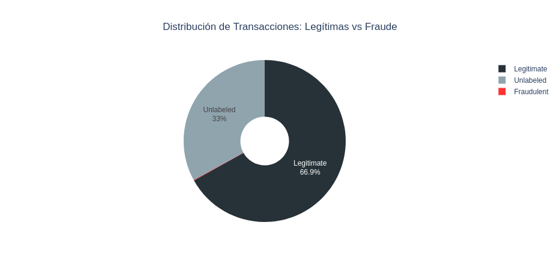

```python
fraud_perc_fig = px.pie(
    fraud_perc_df ,
    values='Total',
    names='target',
    title= 'Distribución de Transacciones: Legítimas vs Fraude',
    color='target',
    color_discrete_map={'Legitimate': '#263238', 'Fraudulent': '#FF3333', 'Unlabeled': '#90A4AE'},
    hole=0.3
    )
fraud_perc_fig.update_traces(
    textposition='inside',
    textinfo='percent+label',
    )
fraud_perc_fig.update_layout(width=650, height=450, title_x=0.5, autosize=False)

fraud_perc_fig.show()
```

```python
val_min = fraud_date_df.select(pl.col("day").min()).collect().item()
val_max = fraud_date_df.select(pl.col("day").max()).collect().item()
print(F"Minimum date: {val_min}\nMaximum date: {val_max}")
```

```
Minimum date: 2010-01-01
Maximum date: 2019-10-31
```

```python
transactions_evolution_df = (
    fraud_date_df
    .group_by("day", "target")
    .len()
    .sort("day")
    .collect()
)
transactions_evolution_df.show(10)
```

shape: (10, 3)

| day date | target str | len u32 |
| --- | --- | --- |
| 2010-01-01 | "Unlabeled" | 1134 |
| 2010-01-01 | "Fraudulent" | 1 |
| 2010-01-01 | "Legitimate" | 2328 |
| 2010-01-02 | "Legitimate" | 1971 |
| 2010-01-02 | "Unlabeled" | 1018 |
| 2010-01-03 | "Fraudulent" | 1 |
| 2010-01-03 | "Unlabeled" | 1110 |
| 2010-01-03 | "Legitimate" | 2200 |
| 2010-01-04 | "Unlabeled" | 1028 |
| 2010-01-04 | "Legitimate" | 2214 |

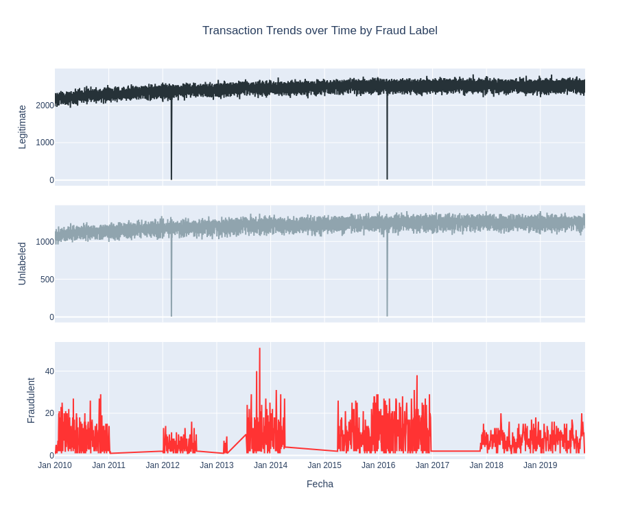

```python
transactions_evolution_false = transactions_evolution_df.filter(pl.col('target') == 'Legitimate')
transactions_evolution_true = transactions_evolution_df.filter(pl.col('target') == 'Fraudulent')
transactions_evolution_null = transactions_evolution_df.filter(pl.col('target') == 'Unlabeled')

transactions_evolution_plot = go.Figure()

transactions_evolution_plot.add_trace(go.Scatter(
    x=transactions_evolution_false['day'],
    y=transactions_evolution_false['len'],
    name='Legitimate',
    line=dict(color='#263238', width=2),
    yaxis='y'
))

transactions_evolution_plot.add_trace(go.Scatter(
    x=transactions_evolution_null['day'],
    y=transactions_evolution_null['len'],
    name='Unlabeled',
    line=dict(color='#90A4AE', width=2),
    yaxis='y2'
))

transactions_evolution_plot.add_trace(go.Scatter(
    x=transactions_evolution_true['day'],
    y=transactions_evolution_true['len'],
    name='Fraudulent',
    line=dict(color='#FF3333', width=2),
    yaxis='y3'
))

transactions_evolution_plot.update_layout(
    title_text='Transaction Trends over Time by Fraud Label', title_x=0.5,
    width=900, height=750, autosize = False,
    hovermode='x',
    legend_title_text='', showlegend=False,

    yaxis=dict(
        title= dict(text='Legitimate', standoff=10),
        domain=[0.7, 1.0],
        showspikes=True, spikemode='across', spikethickness=1, spikedash='dash', spikecolor="#040404"
    ),

    yaxis2=dict(
        title= dict(text='Unlabeled', standoff=10),
        domain=[0.35, 0.65],
        showspikes=True, spikemode='across', spikethickness=1, spikedash='dash', spikecolor="#040404"
    ),

    yaxis3=dict(
        title=dict(text='Fraudulent', standoff=10),
        domain=[0.0, 0.30],
        showspikes=True, spikemode='across', spikethickness=1, spikedash='dash', spikecolor="#040404"
    ),

    xaxis=dict(
        title='Fecha',
        tickformat='%b %Y',
        hoverformat='%A, %d %b %Y',
        showspikes=True, spikemode='across', spikethickness=1, spikedash='dash', spikecolor="#040404",
        anchor='y3',
        side='bottom'
    )
)

transactions_evolution_plot.show()
```

```python
date_fraud_unbiased_df = (
    fraud_date_df
    .filter(
        ((pl.col("day").is_between(date(2010, 1, 1), date(2011, 1, 8))) |
         (pl.col("day").is_between(date(2013, 7, 19), date(2014, 4, 8))) |
         (pl.col("day").is_between(date(2015, 3, 30), date(2016, 12, 22)))
        ) &
        (pl.col("day") != date(2016, 2, 29)) &
        (pl.col("target") != "Unlabeled")
    )
    .with_columns(
        hour = pl.col("date").dt.hour(),
        minute = pl.col("date").dt.minute(),
        time_str = pl.col("date").dt.to_string("%H:%M"),
    )
    .with_columns(minutes_of_day = (pl.col("hour").cast(pl.Int32) * 60) + pl.col("minute"))
    .select("target", "client_id", "day", "time_str", "minutes_of_day", "use_chip", "amount")
)

Rows_unbiased = date_fraud_unbiased_df.select(pl.len()).collect().item()
Columns_unbiased = len(date_fraud_unbiased_df.collect_schema().names())

print(f"Rows: {Rows_unbiased}, Columns: {Columns_unbiased}")
date_fraud_unbiased_df.show(5)
```

shape: (5, 7)

| target str | client_id str | day date | time_str str | minutes_of_day i32 | use_chip cat | amount f64 |
| --- | --- | --- | --- | --- | --- | --- |
| "Legitimate" | "822" | 2010-01-01 | "06:55" | 415 | "Swipe Transaction" | 10.64 |
| "Legitimate" | "1147" | 2010-01-01 | "06:59" | 419 | "Swipe Transaction" | 6.71 |
| "Legitimate" | "1541" | 2010-01-01 | "08:29" | 509 | "Swipe Transaction" | -90.0 |
| "Legitimate" | "148" | 2010-01-01 | "07:21" | 441 | "Swipe Transaction" | 8.6 |
| "Legitimate" | "1248" | 2010-01-01 | "07:11" | 431 | "Swipe Transaction" | 72.85 |

```python
fraud_unbiased_perc_df = (
    date_fraud_unbiased_df
    .group_by("target")
    .agg(
        Total = pl.len(),
        Percentage = pl.len() / Rows_unbiased * 100
    )
    .collect()
)

fraud_unbiased_perc_df.show()
```

shape: (2, 3)

| target str | Total u32 | Percentage f64 |
| --- | --- | --- |
| "Legitimate" | 3119448 | 99.706644 |
| "Fraudulent" | 9178 | 0.293356 |

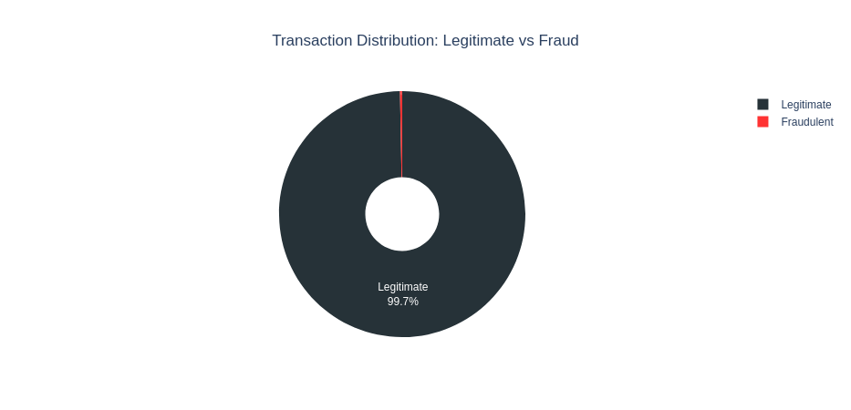

```python
fraud_unbiased_perc_fig = px.pie(
    fraud_unbiased_perc_df,
    values='Total',
    names='target',
    title= 'Transaction Distribution: Legitimate vs Fraud',
    color='target',
    color_discrete_map={'Legitimate': '#263238', 'Fraudulent': '#FF3333'},
    hole=0.3
    )

fraud_unbiased_perc_fig.update_traces(
    textposition='inside',
    textinfo='percent+label',
    )
fraud_unbiased_perc_fig.update_layout(width=650, height=450, title_x=0.5, autosize=False)

fraud_unbiased_perc_fig.show()
```

```python
transactions_evolution_unbiased_df = (
    date_fraud_unbiased_df
    .group_by("day", "target")
    .len()
    .sort("day")
    .collect()
)

transactions_evolution_unbiased_df.show(10)
```

shape: (10, 3)

| day date | target str | len u32 |
| --- | --- | --- |
| 2010-01-01 | "Legitimate" | 2328 |
| 2010-01-01 | "Fraudulent" | 1 |
| 2010-01-02 | "Legitimate" | 1971 |
| 2010-01-03 | "Legitimate" | 2200 |
| 2010-01-03 | "Fraudulent" | 1 |
| 2010-01-04 | "Fraudulent" | 2 |
| 2010-01-04 | "Legitimate" | 2214 |
| 2010-01-05 | "Fraudulent" | 1 |
| 2010-01-05 | "Legitimate" | 2268 |
| 2010-01-06 | "Legitimate" | 2318 |

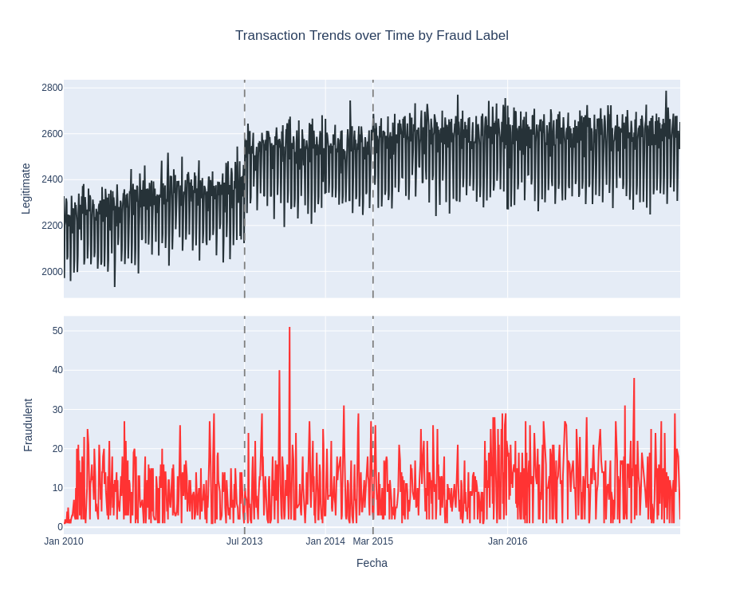

```python
transactions_evolution_unbiased_false = transactions_evolution_unbiased_df.filter(pl.col('target') == 'Legitimate')
transactions_evolution_unbiased_true = transactions_evolution_unbiased_df.filter(pl.col('target') == 'Fraudulent')

transactions_evolution_unbiased_plot = go.Figure()

transactions_evolution_unbiased_plot.add_trace(go.Scatter(
    x=transactions_evolution_unbiased_false['day'],
    y=transactions_evolution_unbiased_false['len'],
    name='Legitimate',
    line=dict(color='#263238', width=2),
    xaxis='x',
    yaxis='y'
))

transactions_evolution_unbiased_plot.add_trace(go.Scatter(
    x=transactions_evolution_unbiased_true['day'],
    y=transactions_evolution_unbiased_true['len'],
    name='Fraudulent',
    line=dict(color='#FF3333', width=2),
    xaxis='x',
    yaxis='y2'
))

transactions_evolution_unbiased_plot.update_layout(
    title_text='Transaction Trends over Time by Fraud Label', title_x=0.5,
    width=900, height=750, autosize=False,
    hovermode='x',
    legend_title_text='', showlegend=False,

    yaxis=dict(
        title= dict(text='Legitimate', standoff=10),
        domain=[0.52, 1.0],
        showspikes=True, spikemode='across', spikethickness=1, spikedash='dash', spikecolor="#040404"
    ),

    yaxis2=dict(
        title= dict(text='Fraudulent', standoff=20),
        domain=[0.0, 0.48],
        showspikes=True, spikemode='across', spikethickness=1, spikedash='dash', spikecolor="#040404"
    ),

    xaxis=dict(
        title='Fecha',
        type='date', tickformat='%b %Y', hoverformat='%A, %d %b %Y',
        showspikes=True, spikemode='across', spikethickness=1, spikedash='dash', spikecolor="#040404",
        anchor='y2', side='bottom',
        rangebreaks=[
            dict(bounds=["2011-01-09", "2013-07-18"]),
            dict(bounds=["2014-04-09", "2015-03-29"])
        ]
    )
)

for fecha in ["2011-01-09", "2013-07-18", "2014-04-09", "2015-03-29"]:
    transactions_evolution_unbiased_plot.add_shape(
        type="line", xref="x", yref="paper",
        x0=fecha, x1=fecha, y0=0.52, y1=1.0,
        line=dict(color="gray", width=1.5, dash="dash")
)

for fecha in ["2011-01-09", "2013-07-18", "2014-04-09", "2015-03-29"]:
    transactions_evolution_unbiased_plot.add_shape(
        type="line", xref="x", yref="paper",
        x0=fecha, x1=fecha, y0=0.0, y1=0.48,
        line=dict(color="gray", width=1.5, dash="dash")
)

transactions_evolution_unbiased_plot.show()
```

```python
monthly_unbiased_df = (
    transactions_evolution_unbiased_df
    .with_columns(
        month_num = pl.col("day").dt.month(),
        month_name= pl.col("day").dt.to_string("%B")
    )
    .group_by("month_num", "month_name", "target")
    .agg(Average_Transactions = pl.col("len").mean())
    .sort("month_num", "target")
)

monthly_unbiased_df.show(10)
```

shape: (10, 4)

| month_num i8 | month_name str | target str | Average_Transactions f64 |
| --- | --- | --- | --- |
| 1 | "January" | "Fraudulent" | 8.56 |
| 1 | "January" | "Legitimate" | 2406.366337 |
| 2 | "February" | "Fraudulent" | 10.285714 |
| 2 | "February" | "Legitimate" | 2426.916667 |
| 3 | "March" | "Fraudulent" | 11.296875 |
| 3 | "March" | "Legitimate" | 2427.210526 |
| 4 | "April" | "Fraudulent" | 10.013514 |
| 4 | "April" | "Legitimate" | 2428.316327 |
| 5 | "May" | "Fraudulent" | 10.393939 |
| 5 | "May" | "Legitimate" | 2444.989247 |

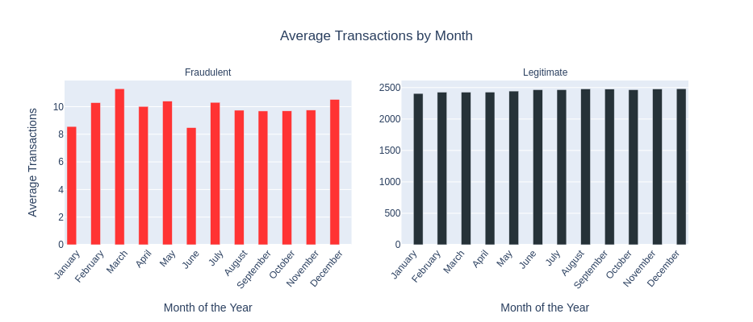

```python
monthly_unbiased_plot = px.bar(
    monthly_unbiased_df,
    x="month_name",
    y="Average_Transactions",
    color="target",
    facet_col="target",
    facet_col_spacing=0.08,
    barmode="group",
    title="Average Transactions by Month",
    labels={
        "month_name": "Month of the Year",
        "Average_Transactions": "Average Transactions",
        "target": ""
    },
    color_discrete_map={'Legitimate': "#263238", 'Fraudulent': "#FF3333"}
)

monthly_unbiased_plot.update_traces(
    hovertemplate="Avg: %{y:,.2f}<extra></extra>"
)

monthly_unbiased_plot.update_yaxes(matches=None, showticklabels=True)
monthly_unbiased_plot.update_xaxes(showticklabels=True, tickangle=-50)

monthly_unbiased_plot.update_layout(
    title_x=0.5, hovermode="closest",
    width=900, height=400, autosize=False,
    showlegend=False
)

monthly_unbiased_plot.for_each_annotation(lambda a: a.update(text=a.text.split('=')[-1]))

monthly_unbiased_plot.show()
```

```python
weekday_unbiased_df = (
    transactions_evolution_unbiased_df
    .with_columns(
        weekday_num = pl.col("day").dt.weekday(),
        weekday_name = pl.col("day").dt.to_string("%A")
    )
    .group_by("weekday_num", "weekday_name", "target")
    .agg(Avg = pl.col("len").mean())
    .sort("weekday_num")
)

weekday_unbiased_df.show(10)
```

shape: (10, 4)

| weekday_num i8 | weekday_name str | target str | Avg f64 |
| --- | --- | --- | --- |
| 1 | "Monday" | "Fraudulent" | 8.506494 |
| 1 | "Monday" | "Legitimate" | 2519.414365 |
| 2 | "Tuesday" | "Fraudulent" | 9.207547 |
| 2 | "Tuesday" | "Legitimate" | 2480.626374 |
| 3 | "Wednesday" | "Fraudulent" | 5.448276 |
| 3 | "Wednesday" | "Legitimate" | 2482.662983 |
| 4 | "Thursday" | "Legitimate" | 2463.022099 |
| 4 | "Thursday" | "Fraudulent" | 9.309524 |
| 5 | "Friday" | "Legitimate" | 2326.379121 |
| 5 | "Friday" | "Fraudulent" | 11.162791 |

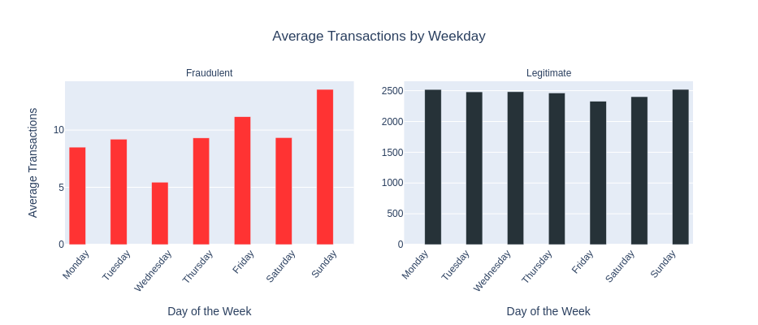

```python
weekday_unbiased_plot = px.bar(
    weekday_unbiased_df,
    x="weekday_name",
    y="Avg",
    color="target",
    facet_col="target",
    facet_col_spacing=0.08,
    barmode="group",
    title="Average Transactions by Weekday",
    labels={"weekday_name": "Day of the Week", "Avg": "Average Transactions","target": ""},
    color_discrete_map={'Legitimate': "#263238", 'Fraudulent': "#FF3333"}
)

weekday_unbiased_plot.update_traces(
    hovertemplate="Avg: %{y:,.2f}<extra></extra>"
)

weekday_unbiased_plot.update_yaxes(matches=None, showticklabels=True)
weekday_unbiased_plot.update_xaxes(showticklabels=True, tickangle=-50)

weekday_unbiased_plot.update_layout(
    title_x=0.5,
    width=900, height=400, autosize=False,
    hovermode="closest",
    showlegend=False
)

weekday_unbiased_plot.for_each_annotation(lambda a: a.update(text=a.text.split('=')[-1]))

weekday_unbiased_plot.show()
```

```python
monthday_unbiased_df = (
    transactions_evolution_unbiased_df
    .with_columns(day_of_month = pl.col("day").dt.day())
    .group_by("day_of_month", "target")
    .agg(Average_Transactions = pl.col("len").mean())
    .sort("day_of_month")
)

monthday_unbiased_df.show(10)
```

shape: (10, 3)

| day_of_month i8 | target str | Average_Transactions f64 |
| --- | --- | --- |
| 1 | "Fraudulent" | 8.764706 |
| 1 | "Legitimate" | 2486.069767 |
| 2 | "Legitimate" | 2440.093023 |
| 2 | "Fraudulent" | 8.870968 |
| 3 | "Fraudulent" | 8.515152 |
| 3 | "Legitimate" | 2434.27907 |
| 4 | "Legitimate" | 2463.511628 |
| 4 | "Fraudulent" | 9.689655 |
| 5 | "Fraudulent" | 10.575758 |
| 5 | "Legitimate" | 2452.465116 |

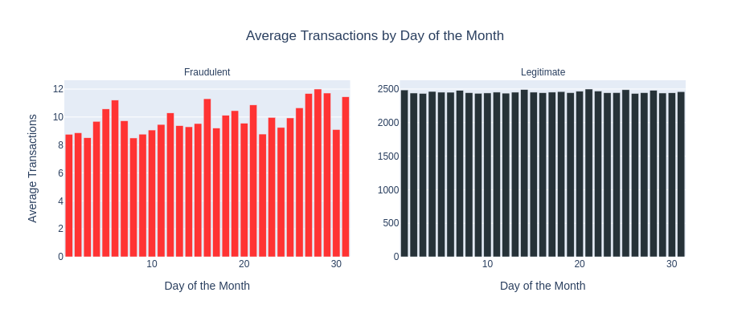

```python
month_day_plot = px.bar(
    monthday_unbiased_df,
    x="day_of_month",
    y="Average_Transactions",
    color="target",
    facet_col="target",
    facet_col_spacing=0.08,
    title="Average Transactions by Day of the Month",
    labels={
        "day_of_month": "Day of the Month",
        "Average_Transactions": "Average Transactions",
        "target": ""
    },
    color_discrete_map={'Legitimate': "#263238", 'Fraudulent': "#FF3333"}
)

month_day_plot.update_traces(
    hovertemplate="Average: %{y:,.2f}<extra></extra>"
)

month_day_plot.update_yaxes(matches=None, showticklabels=True)
month_day_plot.update_xaxes(showticklabels=True)

month_day_plot.update_layout(
    title_x=0.5,
    width=900, height=400, autosize=False,
    hovermode="x unified",
    showlegend=False

)

month_day_plot.for_each_annotation(lambda a: a.update(text=a.text.split('=')[-1]))

month_day_plot.show()
```

```python
detailed_calendar_unbiased_df = (
    transactions_evolution_unbiased_df
    .with_columns(
        day_of_month = pl.col("day").dt.day(),
        weekday_num = pl.col("day").dt.weekday(),
        weekday_name = pl.col("day").dt.to_string("%A")
    )
    .group_by("day_of_month", "weekday_num", "weekday_name", "target")
    .agg(Avg = pl.col("len").mean())
    .sort("day_of_month", "weekday_num", "target")
)

Rows_cal = detailed_calendar_unbiased_df.height
Columns_cal = detailed_calendar_unbiased_df.width
print(f"Rows: {Rows_cal}, Columns: {Columns_cal}")
detailed_calendar_unbiased_df.show(20)
```

shape: (20, 5)

| day_of_month i8 | weekday_num i8 | weekday_name str | target str | Avg f64 |
| --- | --- | --- | --- | --- |
| 1 | 1 | "Monday" | "Fraudulent" | 8.4 |
| 1 | 1 | "Monday" | "Legitimate" | 2493.166667 |
| 1 | 2 | "Tuesday" | "Fraudulent" | 9.333333 |
| 1 | 2 | "Tuesday" | "Legitimate" | 2553.285714 |
| 1 | 3 | "Wednesday" | "Fraudulent" | 4.0 |
| 1 | 3 | "Wednesday" | "Legitimate" | 2531.5 |
| 1 | 4 | "Thursday" | "Fraudulent" | 7.0 |
| 1 | 4 | "Thursday" | "Legitimate" | 2492.166667 |
| 1 | 5 | "Friday" | "Fraudulent" | 10.4 |
| 1 | 5 | "Friday" | "Legitimate" | 2384.857143 |
| 1 | 6 | "Saturday" | "Fraudulent" | 13.0 |
| 1 | 6 | "Saturday" | "Legitimate" | 2444.833333 |
| 1 | 7 | "Sunday" | "Fraudulent" | 10.8 |
| 1 | 7 | "Sunday" | "Legitimate" | 2512.8 |
| 2 | 1 | "Monday" | "Fraudulent" | 5.5 |
| 2 | 1 | "Monday" | "Legitimate" | 2559.6 |
| 2 | 2 | "Tuesday" | "Fraudulent" | 8.5 |
| 2 | 2 | "Tuesday" | "Legitimate" | 2458.833333 |
| 2 | 3 | "Wednesday" | "Fraudulent" | 9.6 |
| 2 | 3 | "Wednesday" | "Legitimate" | 2503.142857 |

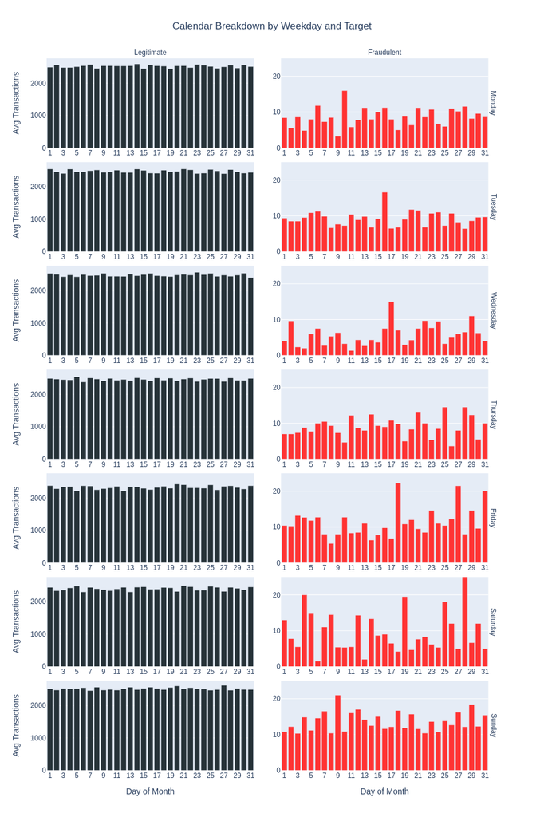

```python
detailed_calendar_unbiased_df = detailed_calendar_unbiased_df.with_columns(
    pl.col("day_of_month").cast(pl.String)
)

fig_calendar = px.bar(
    detailed_calendar_unbiased_df,
    x="day_of_month",
    y="Avg",
    color="target",
    facet_col="target",
    facet_row="weekday_name",
    facet_row_spacing=0.02,
    facet_col_spacing=0.06,
    title="Calendar Breakdown by Weekday and Target",
    labels={"day_of_month": "Day of Month", "Avg": "Avg Transactions", "target": "Is Fraud?"},
    color_discrete_map={'Legitimate': "#263238", 'Fraudulent': "#FF3333"},
    category_orders={"target": ["Legitimate", "Fraudulent"]}
)

fig_calendar.update_yaxes(matches="y", showticklabels=True, col=1)
fig_calendar.update_yaxes(matches="y2", showticklabels=True, col=2, range=[0.0, 25])

fig_calendar.update_xaxes(showticklabels=True)

fig_calendar.update_traces(hovertemplate="Day:%{x}<br>Avg: %{y:,.2f}<extra></extra>")

fig_calendar.update_layout(
    title_x=0.5,
    width=900, height=1400, autosize=False,
    hovermode="closest", showlegend=False
)

fig_calendar.for_each_annotation(lambda a: a.update(text=a.text.split('=')[-1]))

fig_calendar.show()
```

```python
time_fraud_unbiased_df = (
    date_fraud_unbiased_df
    .group_by("minutes_of_day", "time_str", "target")
    .len()
    .sort("minutes_of_day")
    .collect()
)

time_fraud_unbiased_df.show(10)
```

shape: (10, 4)

| minutes_of_day i32 | time_str str | target str | len u32 |
| --- | --- | --- | --- |
| 0 | "00:00" | "Legitimate" | 551 |
| 1 | "00:01" | "Fraudulent" | 1 |
| 1 | "00:01" | "Legitimate" | 510 |
| 2 | "00:02" | "Legitimate" | 510 |
| 3 | "00:03" | "Legitimate" | 482 |
| 4 | "00:04" | "Legitimate" | 486 |
| 5 | "00:05" | "Legitimate" | 506 |
| 6 | "00:06" | "Legitimate" | 510 |
| 7 | "00:07" | "Legitimate" | 495 |
| 7 | "00:07" | "Fraudulent" | 1 |

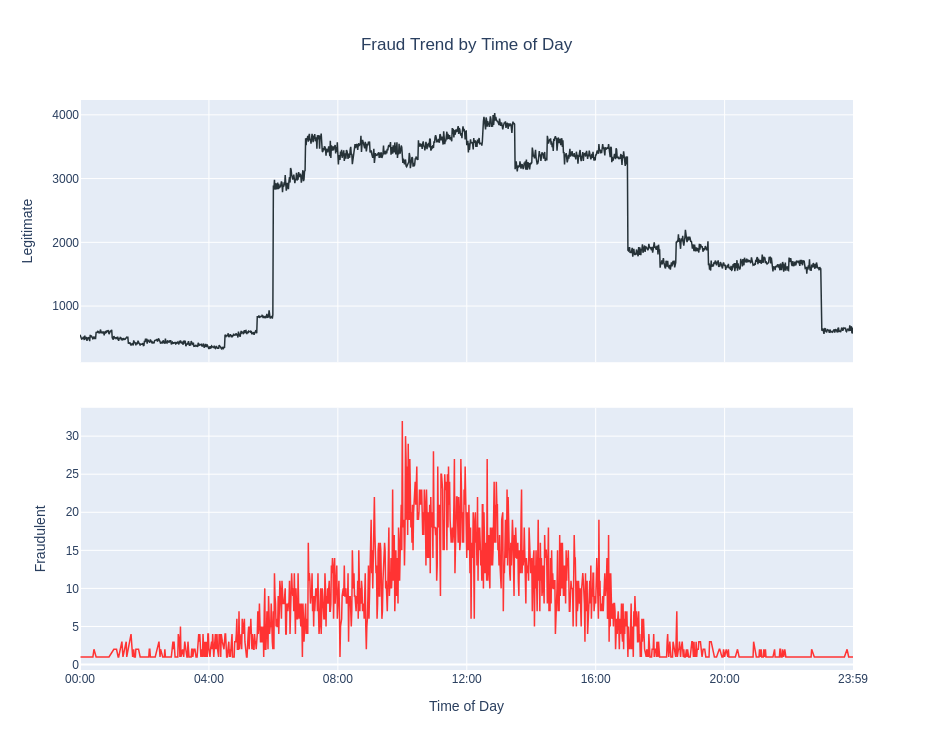

```python
time_fraud_false = time_fraud_unbiased_df.filter(pl.col('target') == 'Legitimate')
time_fraud_true = time_fraud_unbiased_df.filter(pl.col('target') == 'Fraudulent')

time_evolution_plot = go.Figure()

time_evolution_plot.add_trace(go.Scatter(
    x=time_fraud_false['minutes_of_day'],
    y=time_fraud_false['len'],
    name='Legitimate',
    mode='lines',
    line=dict(color='#263238', width=1.5),
    xaxis='x', yaxis='y',
    customdata=time_fraud_false['time_str'],
    hovertemplate="Time: %{customdata}<br>Count: %{y:,.0f}<extra></extra>"
))

time_evolution_plot.add_trace(go.Scatter(
    x=time_fraud_true['minutes_of_day'],
    y=time_fraud_true['len'],
    name='Fraudulent',
    mode='lines',
    line=dict(color='#FF3333', width=1.5),
    xaxis='x', yaxis='y2',
    customdata=time_fraud_true['time_str'],
    hovertemplate="Time: %{customdata}<br>Count: %{y:,.0f}<extra></extra>"
))

time_evolution_plot.update_layout(
    title_text='Fraud Trend by Time of Day',
    title_x=0.5,
    width=900, height=750,
    hovermode='closest',
    showlegend=False,

    yaxis=dict(
        title=dict(text='Legitimate'),
        domain=[0.54, 1.0],
        showspikes=True, spikemode='across', spikethickness=1, spikedash='dash', spikecolor="#040404"),
    yaxis2=dict(
        title=dict(text='Fraudulent'),
        domain=[0.0, 0.46],
        showspikes=True, spikemode='across', spikethickness=1, spikedash='dash', spikecolor="#040404"),

    xaxis=dict(
        title='Time of Day',
        showspikes=True, spikemode='across', spikethickness=1, spikedash='dash', spikecolor="#040404",
        anchor='y2', side='bottom',
        tickmode="array",
        tickvals=[0, 240, 480, 720, 960, 1200, 1439],
        ticktext=["00:00", "04:00", "08:00", "12:00", "16:00", "20:00", "23:59"]
    )
)

time_evolution_plot.show()
```

```python
date_fraud_unbiased_df.show(10)
```

shape: (10, 7)

| target str | client_id str | day date | time_str str | minutes_of_day i32 | use_chip cat | amount f64 |
| --- | --- | --- | --- | --- | --- | --- |
| "Legitimate" | "822" | 2010-01-01 | "06:55" | 415 | "Swipe Transaction" | 10.64 |
| "Legitimate" | "1147" | 2010-01-01 | "06:59" | 419 | "Swipe Transaction" | 6.71 |
| "Legitimate" | "1541" | 2010-01-01 | "08:29" | 509 | "Swipe Transaction" | -90.0 |
| "Legitimate" | "148" | 2010-01-01 | "07:21" | 441 | "Swipe Transaction" | 8.6 |
| "Legitimate" | "1248" | 2010-01-01 | "07:11" | 431 | "Swipe Transaction" | 72.85 |
| "Legitimate" | "754" | 2010-01-01 | "06:23" | 383 | "Swipe Transaction" | 39.07 |
| "Legitimate" | "319" | 2010-01-01 | "03:17" | 197 | "Swipe Transaction" | 29.6 |
| "Legitimate" | "354" | 2010-01-01 | "07:09" | 429 | "Swipe Transaction" | 5.76 |
| "Legitimate" | "1313" | 2010-01-01 | "02:57" | 177 | "Swipe Transaction" | 2.77 |
| "Legitimate" | "1703" | 2010-01-01 | "01:23" | 83 | "Swipe Transaction" | 71.72 |

```python
fraudulent_client_df = (
    date_fraud_unbiased_df
    .select("client_id", "target")
    .filter(pl.col("target") == 'Fraudulent')
    .unique()
    .collect()
)

fraudulent_client_list = fraudulent_client_df["client_id"].to_list()
print("Total Clients with Fraudulent Transactions:", len(fraudulent_client_list))
```

```
Total Clients with Fraudulent Transactions: 1045
```

```python
client_df = (
    date_fraud_unbiased_df
    .filter(pl.col("client_id").is_in(fraudulent_client_list))
    .select("client_id", "day", "time_str", "minutes_of_day", "use_chip", "target", "amount")
)

Rows_client = client_df.select(pl.len()).collect().item()
Columns_client = len(client_df.collect_schema().names())

print(f"Rows: {Rows_client}, Columns: {Columns_client}")
client_df.show(5)
```

shape: (5, 7)

| client_id str | day date | time_str str | minutes_of_day i32 | use_chip cat | target str | amount f64 |
| --- | --- | --- | --- | --- | --- | --- |
| "822" | 2010-01-01 | "06:55" | 415 | "Swipe Transaction" | "Legitimate" | 10.64 |
| "1147" | 2010-01-01 | "06:59" | 419 | "Swipe Transaction" | "Legitimate" | 6.71 |
| "1541" | 2010-01-01 | "08:29" | 509 | "Swipe Transaction" | "Legitimate" | -90.0 |
| "148" | 2010-01-01 | "07:21" | 441 | "Swipe Transaction" | "Legitimate" | 8.6 |
| "1248" | 2010-01-01 | "07:11" | 431 | "Swipe Transaction" | "Legitimate" | 72.85 |

```python
def plot_client_behaviour_time(client_ID):
    client_transaction_df = (
        client_df
        .filter(pl.col("client_id") == client_ID)
        .sort("day")
        .with_columns(
            hover_date_str = pl.col("day").dt.to_string("%A, %d %b %Y"),
            amount_absolute = pl.col("amount").abs(),
            amount_sign = pl.when(pl.col("amount") >= 0).then(pl.lit("Positive")).otherwise(pl.lit("Negative")),
            day_str = pl.col("day").dt.to_string("%Y-%m-%d")
        )
        .collect()
    )

    ordered_days = client_transaction_df["day_str"].unique(maintain_order=True).to_list()

    client_transaction_fig = px.scatter(
        client_transaction_df,
        x="day_str",
        y="minutes_of_day",
        size="amount_absolute",
        symbol="amount_sign",
        symbol_sequence=['circle', 'x'],
        color="target",
        facet_row="use_chip",
        facet_row_spacing=0.08,
        height=750, width=850,
        opacity=0.6,
        category_orders={"target": ["Legitimate", "Fraudulent"]},
        custom_data=["hover_date_str", "use_chip", "time_str", "amount"],
        title= f"<b>Transactions Behaviour, ClientID: {client_ID}</b>",
        labels={"day_str": "Date", "minutes_of_day": "Time"}
    )

    client_transaction_fig.update_traces(
        marker=dict(line=dict(color='black', width=0.45)),
        hovertemplate="<b>%{customdata[0]}</b><br>Chip: %{customdata[1]}\
        <br>time: %{customdata[2]}<br>amount: %{customdata[3]}<extra></extra>"
    )

    client_transaction_fig.update_layout(
        plot_bgcolor="#F5F5F5", paper_bgcolor="white",
        width=900, height=900, autosize=False,
        legend=dict(title="", orientation="h", yanchor="top", y=1.05, xanchor="left", x=0.1)
    )

    client_transaction_fig.update_xaxes(
        showticklabels=True, tickformat="%A, %d %b %Y", matches="x", tickangle=-45, nticks=12,
        type='category', categoryorder='array', categoryarray=ordered_days,
        showspikes=True, spikemode='across', spikethickness=1, spikedash='dash', spikecolor="#040404",

    )

    client_transaction_fig.update_xaxes(showticklabels=False, row=2)
    client_transaction_fig.update_xaxes(showticklabels=False, row=3)

    client_transaction_fig.update_yaxes(
        showgrid=True, gridcolor="#EAEAEA",
        tickvals=[0, 240, 480, 720, 960, 1200, 1439],
        ticktext=["00:00", "04:00", "08:00", "12:00", "16:00", "20:00", "23:59"]
    )

    client_transaction_fig.for_each_annotation(lambda a: a.update(
        text=f"<b>{a.text.split('=')[-1]}</b>",
        font=dict(size=14, color="black")
        )
    )

    client_transaction_fig.add_vline(x="2011-01-08", line_width=1.5, line_dash="dash")
    client_transaction_fig.add_vline(x="2015-03-30", line_width=1.5, line_dash="dash")

    return client_transaction_fig
```

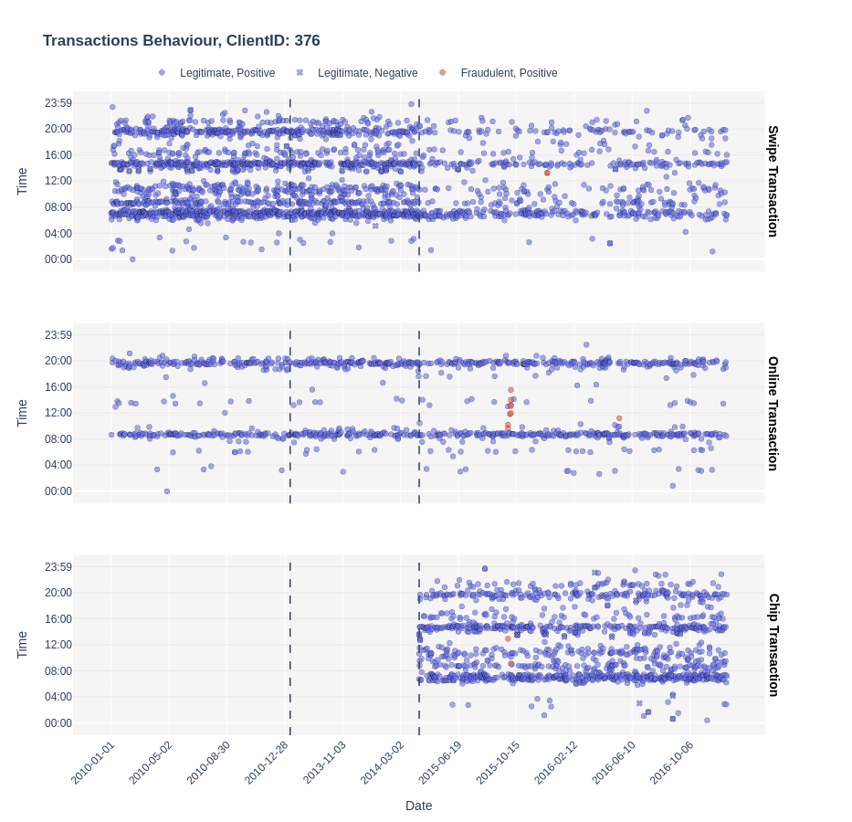

```python
plot_client_behaviour_time("376")
```

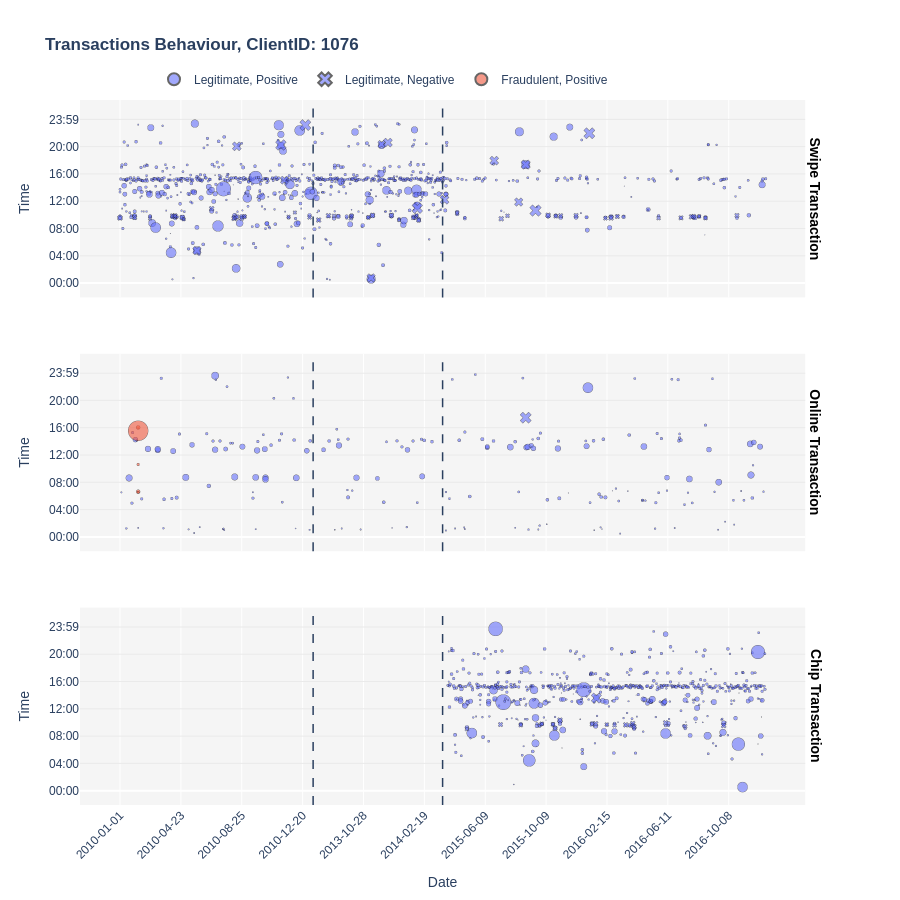

```python
plot_client_behaviour_time(fraudulent_client_list[1])
```

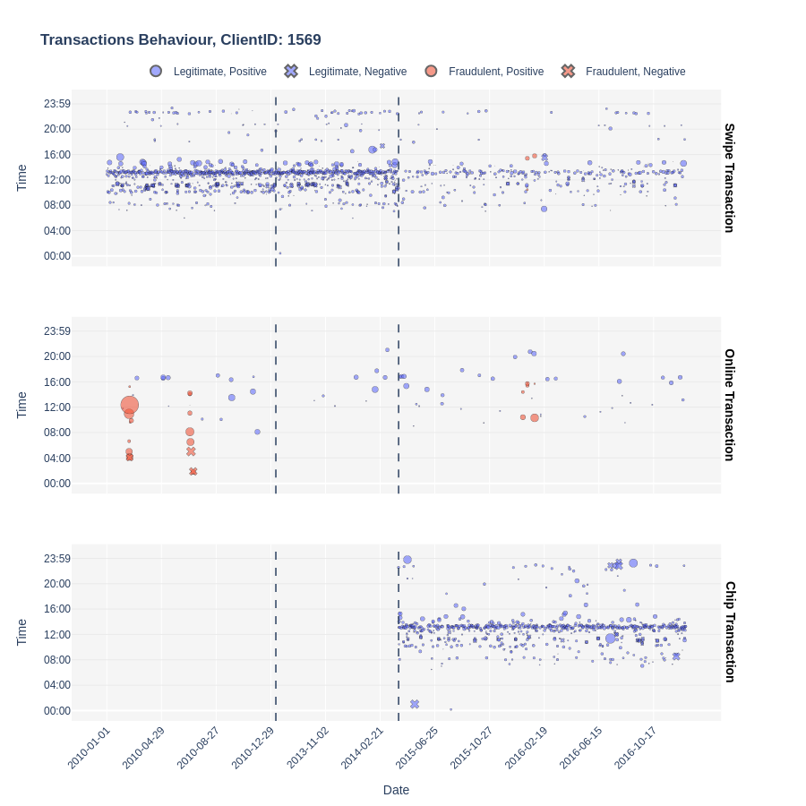

```python
plot_client_behaviour_time(fraudulent_client_list[2])
```

### **3.4. Análisis Exploratorio de Datos Transaccionales**

```python
import polars as pl
import plotly.express as px
import plotly.graph_objects as go
from datetime import date
path = "/home/jovyan/work/data/bronze/Polars/"
```

```python
!ls $path
```

```
complete_fraud_data.parquet
```

```python
amountchip_fraud_unbiased_df = (
    pl.scan_parquet(f"{path}complete_fraud_data.parquet")
    .with_columns(day = pl.col("date").cast(pl.Date))
    .filter(
        ((pl.col("day").is_between(date(2010, 1, 1), date(2011, 1, 8))) |
         (pl.col("day").is_between(date(2013, 7, 19), date(2014, 4, 8))) |
         (pl.col("day").is_between(date(2015, 3, 30), date(2016, 12, 22)))
        ) &
        (pl.col("day") != date(2016, 2, 29)) &
        (pl.col("target").is_not_null())
    )
    .with_columns(
        target = pl.when(pl.col("target")).then(pl.lit("Fraudulent")).otherwise(pl.lit("Legitimate"))
    )
    .select("amount", "target", "use_chip", "day", "client_id")
)

Rows = amountchip_fraud_unbiased_df.select(pl.len()).collect().item()
Columns = len(amountchip_fraud_unbiased_df.collect_schema().names())

print(f"Rows: {Rows}, Columns: {Columns}")
amountchip_fraud_unbiased_df.show(5)
```

shape: (5, 5)

| amount f64 | target str | use_chip cat | day date | client_id str |
| --- | --- | --- | --- | --- |
| 10.64 | "Legitimate" | "Swipe Transaction" | 2010-01-01 | "822" |
| 6.71 | "Legitimate" | "Swipe Transaction" | 2010-01-01 | "1147" |
| -90.0 | "Legitimate" | "Swipe Transaction" | 2010-01-01 | "1541" |
| 8.6 | "Legitimate" | "Swipe Transaction" | 2010-01-01 | "148" |
| 72.85 | "Legitimate" | "Swipe Transaction" | 2010-01-01 | "1248" |

```python
chip_evolution_df = (
    amountchip_fraud_unbiased_df
    .group_by("use_chip", "day", "target")
    .len()
    .sort("use_chip", "day", "target")
    .collect()
)

chip_evolution_df.show(10)
```

shape: (10, 4)

| use_chip cat | day date | target str | len u32 |
| --- | --- | --- | --- |
| "Chip Transaction" | 2015-03-30 | "Fraudulent" | 1 |
| "Chip Transaction" | 2015-03-30 | "Legitimate" | 1922 |
| "Chip Transaction" | 2015-03-31 | "Legitimate" | 1887 |
| "Chip Transaction" | 2015-04-01 | "Legitimate" | 1869 |
| "Chip Transaction" | 2015-04-02 | "Legitimate" | 1692 |
| "Chip Transaction" | 2015-04-03 | "Fraudulent" | 1 |
| "Chip Transaction" | 2015-04-03 | "Legitimate" | 1685 |
| "Chip Transaction" | 2015-04-04 | "Legitimate" | 1881 |
| "Chip Transaction" | 2015-04-05 | "Legitimate" | 1855 |
| "Chip Transaction" | 2015-04-06 | "Fraudulent" | 2 |

```python
chip_color = {
    'Online Transaction': '#7EA1B5',
    'Swipe Transaction': '#F2A183',
    'Chip Transaction': '#89D3C2'
}

chip_order = ["Online Transaction", "Chip Transaction", "Swipe Transaction"]
```

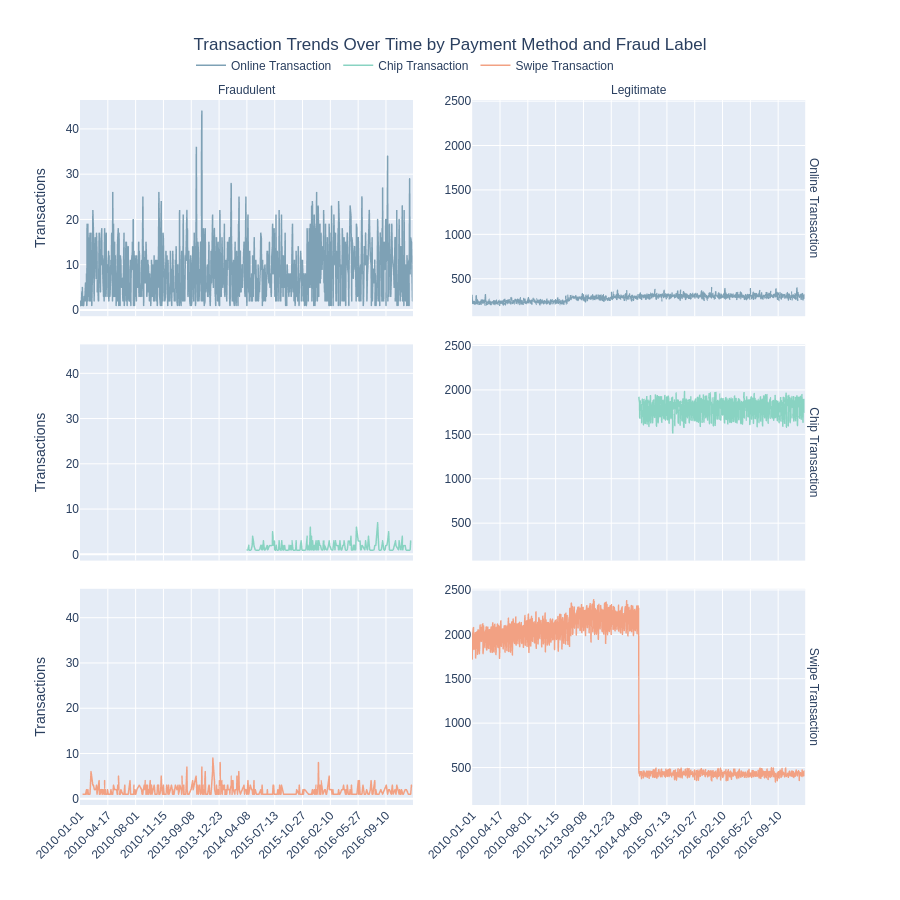

```python
ordered_days = chip_evolution_df['day'].unique().sort()

chip_evolution_plot = px.scatter(
    chip_evolution_df,
    x="day",
    y="len",
    color="use_chip",
    facet_col="target",
    facet_row="use_chip",
    facet_row_spacing=0.04,
    facet_col_spacing=0.08,
    title="Transaction Trends Over Time by Payment Method and Fraud Label",
    labels={"day": "", "len": "Transactions", "target": "Is Fraud?"},
    color_discrete_map= chip_color,
    category_orders={"use_chip": chip_order},
    custom_data=["target"]
)

chip_evolution_plot.update_traces(
    mode="lines",
    line=dict(width=1.5),
    hovertemplate="<b>Date:</b> %{x|%A, %d %b %Y}<br><b>Transactions:</b> %{y:,}<extra></extra>"
)

chip_evolution_plot.update_yaxes(
    showspikes=True, spikemode='across', spikethickness=1, spikedash='dash', spikecolor="#040404"
)

chip_evolution_plot.update_yaxes(matches="y", showticklabels=True, col=1)
chip_evolution_plot.update_yaxes(matches="y2",showticklabels=True, col=2)

chip_evolution_plot.update_xaxes(
    showticklabels=True, tickformat='%b %Y', matches="x", tickangle=-45, nticks=12,
    type='category', categoryorder='array', categoryarray=ordered_days,
    showspikes=True, spikemode='across', spikethickness=1, spikedash='dash', spikecolor="#040404",
)

chip_evolution_plot.update_xaxes(showticklabels=False, row=2)
chip_evolution_plot.update_xaxes(showticklabels=False, row=3)

chip_evolution_plot.update_layout(
    title_x=0.5,
    width=900, height=900, autosize=False,
    hovermode="x",
    legend=dict(title="", orientation="h", yanchor="top", y=1.07, xanchor="left", x=0.15),
)

chip_evolution_plot.for_each_annotation(lambda a: a.update(text=a.text.split('=')[-1]))

chip_evolution_plot.show()
```

Debido a que hay tendencias que no se entiendo más que como falta de registros por sesgos seleccionaremos filtraremos nuestros datos para analizarlos durante elperiodo de un año-, el periodo elegido es de 30 de Marzo de 2015 a 29 de Marzo de 2016. Ya que antes de esa fecha no hay registro de transacciones con chip, lo cual puede entorpecer el modelado. Además de que a partir de esa fecha se observa un amplio descenso en el número de operaciones swipe, sin embargo esto no va de la mano con un descenso en el número de registros de fraude, por lo que a priori se fortalece la idea de que hay un error en el registro.  
Buscar cuando salio nueva tarjeta para uso de pin

```python
amountchip_fraud_unbiased2_df = (
    amountchip_fraud_unbiased_df.filter(pl.col("day").is_between(date(2015, 3, 30), date(2016, 3, 29)))
)

amountchip_fraud_unbiased2_df.show(5)
```

shape: (5, 5)

| amount f64 | target str | use_chip cat | day date | client_id str |
| --- | --- | --- | --- | --- |
| 100.0 | "Legitimate" | "Swipe Transaction" | 2015-04-11 | "241" |
| 2.57 | "Legitimate" | "Chip Transaction" | 2015-04-12 | "920" |
| 45.78 | "Legitimate" | "Chip Transaction" | 2015-04-10 | "480" |
| 542.96 | "Legitimate" | "Chip Transaction" | 2015-04-10 | "1811" |
| 84.12 | "Legitimate" | "Chip Transaction" | 2015-04-11 | "52" |

```python
total_amountchip_df = (
    amountchip_fraud_unbiased2_df
    .group_by("target", "use_chip")
    .agg(
        total_transactions = pl.col("amount").len(),
        total_amount = pl.col("amount").sum().round(2)
    )
    .sort("total_amount", descending = True)
    .collect()
)

total_amountchip_df.show(10)
```

shape: (6, 4)

| target str | use_chip cat | total_transactions u32 | total_amount f64 |
| --- | --- | --- | --- |
| "Legitimate" | "Chip Transaction" | 660037 | 2.6893e7 |
| "Legitimate" | "Online Transaction" | 112161 | 6.3423e6 |
| "Legitimate" | "Swipe Transaction" | 157719 | 6.3288e6 |
| "Fraudulent" | "Online Transaction" | 2491 | 328862.82 |
| "Fraudulent" | "Chip Transaction" | 240 | 25300.37 |
| "Fraudulent" | "Swipe Transaction" | 183 | 19764.05 |

```python
def total_chip_plot (df, y_total, y_axis):
    total_amountchip_plot = px.bar(
        df,
        x="use_chip",
        y=y_total,
        color="use_chip",
        facet_row="target",
        facet_row_spacing=0.1,
        color_discrete_map=chip_color,
        category_orders={"use_chip": chip_order},
        text_auto=",",
        custom_data=["target"]
    )

    total_amountchip_plot.update_layout(
        plot_bgcolor="white", paper_bgcolor="white", showlegend=True,
        width=600, height=600, autosize=False,
        margin=dict(l=80, r=30, t=60, b=50),
        title=dict(text="<b>Fiscal Year 2016 Transaction Breakdown by Payment Method</b>", x=0.5, font=dict(size=14, color="black")),
        legend=dict(title="", orientation="v", yanchor="top", y=1.05, xanchor="left", x=0.8)
    )

    total_amountchip_plot.update_traces(
        marker_line_color="#4A4A4A", marker_line_width=1.2,
        textposition="outside", textfont=dict(size=11, color="black"), width=0.5,
        hovertemplate="<b>%{x}</b><br>Status: %{customdata[0]}<br>Total: %{y:,}<extra></extra>"
    )

    total_amountchip_plot.update_yaxes(
        title= y_axis,
        gridcolor="#EAEAEA", showline=False, zeroline=False,
        tickfont=dict(size=11, color="black"),
        matches=None, showticklabels=True
    )

    total_amountchip_plot.update_xaxes(
        title="", showgrid=False, linecolor="#D3D3D3",
        tickfont=dict(size=11, color="black", weight="bold"),
        showticklabels=True
    )

    total_amountchip_plot.for_each_annotation(
        lambda a: a.update(
            text="<b>Legitimate</b>" if "Legitimate" in a.text
            else ("<b>Fraudulent</b>" if "Fraudulent" in a.text
            else f"<b>{a.text.split('=')[-1]}</b>")
        )
    )

    return total_amountchip_plot
```

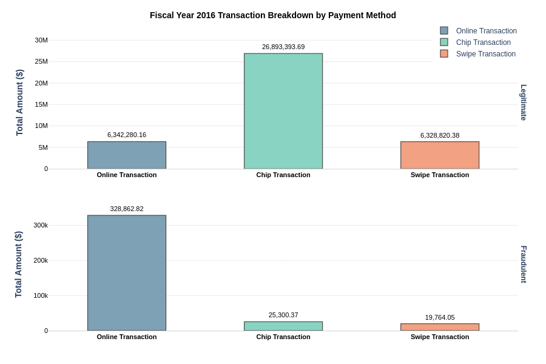

```python
total_chip_plot (total_amountchip_df, "total_amount", "<b>Total Amount ($)</b>")
```

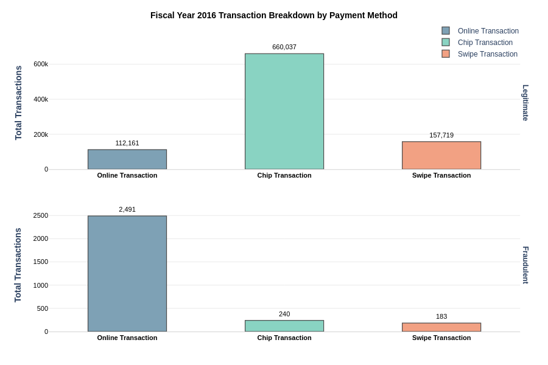

```python
total_chip_plot (total_amountchip_df, "total_transactions", "<b>Total Transactions</b>")
```

```python
ratio_fraud = (
    total_amountchip_df
    .pivot(
        on="target", index="use_chip", values="total_transactions", aggregate_function="sum"
    )
    .with_columns(
        Frauds_per_10k_Transactions =
            pl.col("Fraudulent") / (pl.col("Fraudulent") + pl.col("Legitimate")) * 10000
    )
    .sort("Frauds_per_10k_Transactions", descending = True)
)

ratio_fraud.show()
```

shape: (3, 4)

| use_chip cat | Legitimate u32 | Fraudulent u32 | Frauds_per_10k_Transactions f64 |
| --- | --- | --- | --- |
| "Online Transaction" | 112161 | 2491 | 217.266162 |
| "Swipe Transaction" | 157719 | 183 | 11.589467 |
| "Chip Transaction" | 660037 | 240 | 3.634838 |

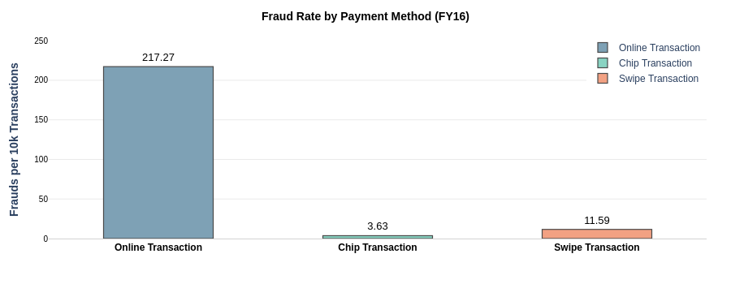

```python
ratio_fraud_plot = px.bar(
    ratio_fraud,
    x="use_chip",
    y="Frauds_per_10k_Transactions",
    color="use_chip",
    color_discrete_map= chip_color,
    category_orders={"use_chip": chip_order},
    text_auto=",.2f"
)

ratio_fraud_plot.update_layout(
    plot_bgcolor="white", paper_bgcolor="white", showlegend=True,
    width=600, height=350, autosize=False, margin=dict(l=60, r=30, t=50, b=50),
    title=dict(text="<b>Fraud Rate by Payment Method (FY16)</b>", x=0.5, font=dict(size=14, color="black"),),
    xaxis=dict(title="", showgrid=False, linecolor="#D3D3D3", tickfont=dict(size=12, color="black", weight="bold")),
    yaxis=dict(title="<b>Frauds per 10k Transactions</b>", gridcolor="#EAEAEA", showline=False, zeroline=False,
               tickfont=dict(size=10, color="black")),
    legend=dict(title="", orientation="v", yanchor="bottom", y=0.75, xanchor="right", x=1),
)

ratio_fraud_plot.update_traces(
    marker_line_color="#4A4A4A", marker_line_width=1.2,
    textposition="outside", textfont=dict(size=13, color="black"),
    width=0.5,
    hovertemplate="<b>%{x}</b><br>Total: %{y:,}$<extra></extra>"
)

ratio_fraud_plot.show()
```

```python
true_amountchip_fraud_unbiased2_df = (
    amountchip_fraud_unbiased2_df
    .filter(pl.col("target") == 'Fraudulent')
    .drop("day")
    .collect()
)

false_amountchip_fraud_unbiased2_df = (
    amountchip_fraud_unbiased2_df
    .filter(pl.col("target") == 'Legitimate')
    .drop("day")
    .collect()
    .sample(fraction=0.004, seed=777)
)

sample_amountchip_fraud_unbiased2_df = pl.concat(
    [false_amountchip_fraud_unbiased2_df, true_amountchip_fraud_unbiased2_df]
)

print(f"Rows: {sample_amountchip_fraud_unbiased2_df.height}")
```

```
Rows: 6633
```

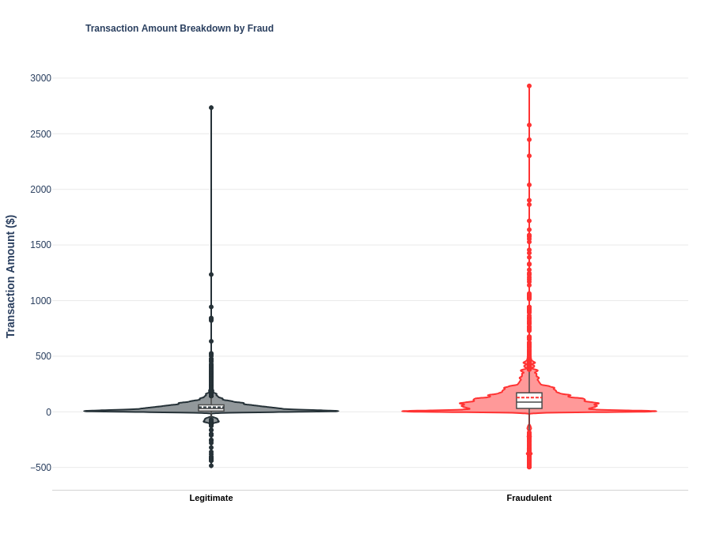

```python
fig_violin = px.violin(
    sample_amountchip_fraud_unbiased2_df,
    x="target",
    y="amount",
    color="target",
    points="outliers",
    labels={"amount": "Transaction Amount ($)", "target": "Is Fraud?"},
    color_discrete_map={'Legitimate': '#263238', 'Fraudulent': '#FF3333'},
    box=True,
)

fig_violin.update_traces(
    box_fillcolor="white", box_line_color="#4A4A4A", box_line_width=1.5, box_width=0.1,
    meanline_visible=True,
    width=0.8, bandwidth=6,
    # hoveron="violins",
)

fig_violin.update_layout(
    plot_bgcolor="white", paper_bgcolor="white", showlegend=False,
    width=900, height=700, margin=dict(l=60, r=30, t=80, b=80),
    title=dict(text="<b>Transaction Amount Breakdown by Fraud</b>", x=0.12,font=dict(size=12),),
    xaxis=dict(title="", showgrid=False, linecolor="#D3D3D3", tickfont=dict(size=11, color="black", weight="bold")),
    yaxis=dict(title="<b>Transaction Amount ($)</b>", gridcolor="#EAEAEA", showline=False, zeroline=False),
)

fig_violin.show()
```

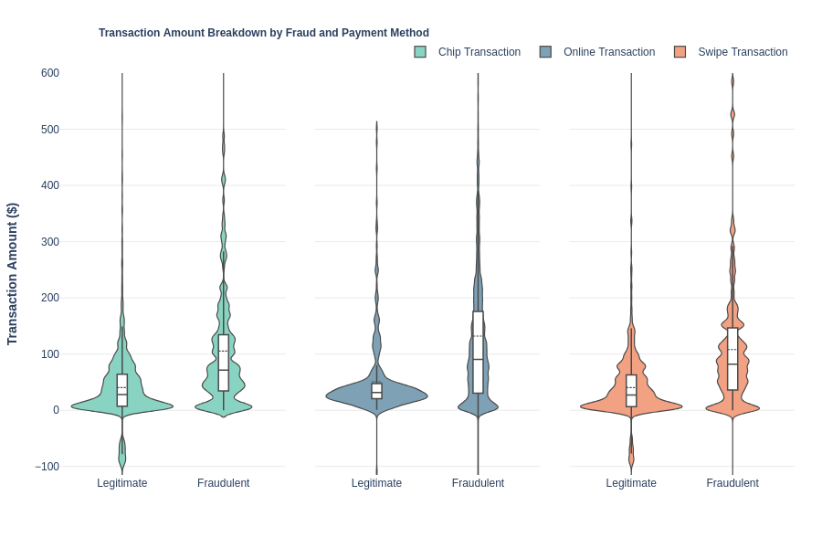

```python
fig = px.violin(
    sample_amountchip_fraud_unbiased2_df,
    x="target",
    y="amount",
    color="use_chip",
    facet_col="use_chip",
    facet_col_spacing=0.04,
    color_discrete_map=chip_color,
    category_orders={"target": chip_order},
    box=True,
    points=False,
)

fig.update_layout(
    violinmode="group", boxmode="group",
    plot_bgcolor="white", paper_bgcolor="white", showlegend=True,
    width=900, height=600, autosize=False, margin=dict(l=60, r=30, t=80, b=80),
    title=dict(text="<b>Transaction Amount Breakdown by Fraud and Payment Method</b>",
               x=0.12,font=dict(size=12),),
    legend=dict(title="", orientation="h", yanchor="bottom", y=1.02, xanchor="right", x=1),
    yaxis=dict(title="<b>Transaction Amount ($)</b>", gridcolor="#EAEAEA", showline=False,
               zeroline=False,
               range=[-115, 600]
              ),
)

fig.update_traces(
    box_fillcolor="white", box_line_color="#4A4A4A", box_line_width=1.5, box_width=0.1,
    meanline_visible=True,
    line=dict(color="#4A4A4A", width=1.2),
    width=1,
    bandwidth=6,
    hoveron="violins",
)

fig.update_yaxes(showgrid=True, gridcolor="#EAEAEA", showline=False, zeroline=False)
fig.update_xaxes(title_text="")
fig.update_annotations(text="")

fig.for_each_trace(lambda trace: trace.update(fillcolor=chip_color.get(trace.name, "#CCCCCC")))

fig.show()
```

Analizamos el historial de transacciones de algunos clientes

```python
fraudulent_client_df = (
    amountchip_fraud_unbiased_df
    .select("client_id", "target")
    .filter(pl.col("target") == 'Fraudulent')
    .unique()
    .collect()
)

fraudulent_client_list = fraudulent_client_df["client_id"].to_list()
print("Total Clients with Fraudulent Transactions:", len(fraudulent_client_list))
```

```
Total Clients with Fraudulent Transactions: 1045
```

```python
client_df = (
    amountchip_fraud_unbiased_df
    .filter(pl.col("client_id").is_in(fraudulent_client_list))
    .select("client_id", "day", "amount", "use_chip", "target")
)

Rows_client = client_df.select(pl.len()).collect().item()
Columns_client = len(client_df.collect_schema().names())

print(f"Rows: {Rows_client}, Columns: {Columns_client}")
client_df.show(5)
```

shape: (5, 5)

| client_id str | day date | amount f64 | use_chip cat | target str |
| --- | --- | --- | --- | --- |
| "822" | 2010-01-01 | 10.64 | "Swipe Transaction" | "Legitimate" |
| "1147" | 2010-01-01 | 6.71 | "Swipe Transaction" | "Legitimate" |
| "1541" | 2010-01-01 | -90.0 | "Swipe Transaction" | "Legitimate" |
| "148" | 2010-01-01 | 8.6 | "Swipe Transaction" | "Legitimate" |
| "1248" | 2010-01-01 | 72.85 | "Swipe Transaction" | "Legitimate" |

```python
def plot_client_behaviour_amount(client_ID):
    client_transaction_df = (
        client_df
        .filter(pl.col("client_id") == client_ID)
        .sort("day")
        .with_columns(
            hover_date_str = pl.col("day").dt.to_string("%A, %d %b %Y"),
            amount_absolute = pl.col("amount").abs(),
            amount_sign = pl.when(pl.col("amount") >= 0).then(pl.lit("Positive")).otherwise(pl.lit("Negative")),
            day_str = pl.col("day").dt.to_string("%Y-%m-%d")
        )
        .collect()
    )

    client_transaction_fig = px.scatter(
        client_transaction_df,
        x="day_str",
        y="amount",
        color="target",
        facet_row="use_chip",
        facet_row_spacing=0.08,
        opacity=0.6,
        category_orders={"target": ["Legitimate", "Fraudulent"]},
        custom_data=["hover_date_str", "use_chip"],
        title= f"<b>Transactions Behaviour, ClientID: {client_ID}</b>",
        labels={"day_str": "Date"}
    )

    client_transaction_fig.update_traces(
        marker=dict(line=dict(color='black', width=0.45)),
        hovertemplate="<b>%{customdata[0]}</b><br>Chip: %{customdata[1]}\
        <br>amount: %{y:,.2f}$<extra></extra>"
    )

    client_transaction_fig.update_layout(
        plot_bgcolor="#F5F5F5", paper_bgcolor="white",
        height=750, width=900, autosize=False,
        legend=dict(title="", orientation="h", yanchor="top", y=1.08, xanchor="left", x=0.65)
    )

    client_transaction_fig.update_xaxes(
        showticklabels=True, tickformat="%A, %d %b %Y", matches="x", tickangle=-45, nticks=12,
        type='category', categoryorder='array', categoryarray=ordered_days,
        showspikes=True, spikemode='across', spikethickness=1, spikedash='dash', spikecolor="#040404",

    )

    client_transaction_fig.update_xaxes(showticklabels=False, row=2)
    client_transaction_fig.update_xaxes(showticklabels=False, row=3)

    client_transaction_fig.update_yaxes(showgrid=True, gridcolor="#EAEAEA")

    client_transaction_fig.for_each_annotation(lambda a: a.update(
        text=f"<b>{a.text.split('=')[-1]}</b>",
        font=dict(size=14, color="black")
        )
    )

    client_transaction_fig.add_vline(x="2011-01-08", line_width=1.5, line_dash="dash")
    client_transaction_fig.add_vline(x="2015-03-30", line_width=1.5, line_dash="dash")

    return client_transaction_fig
```

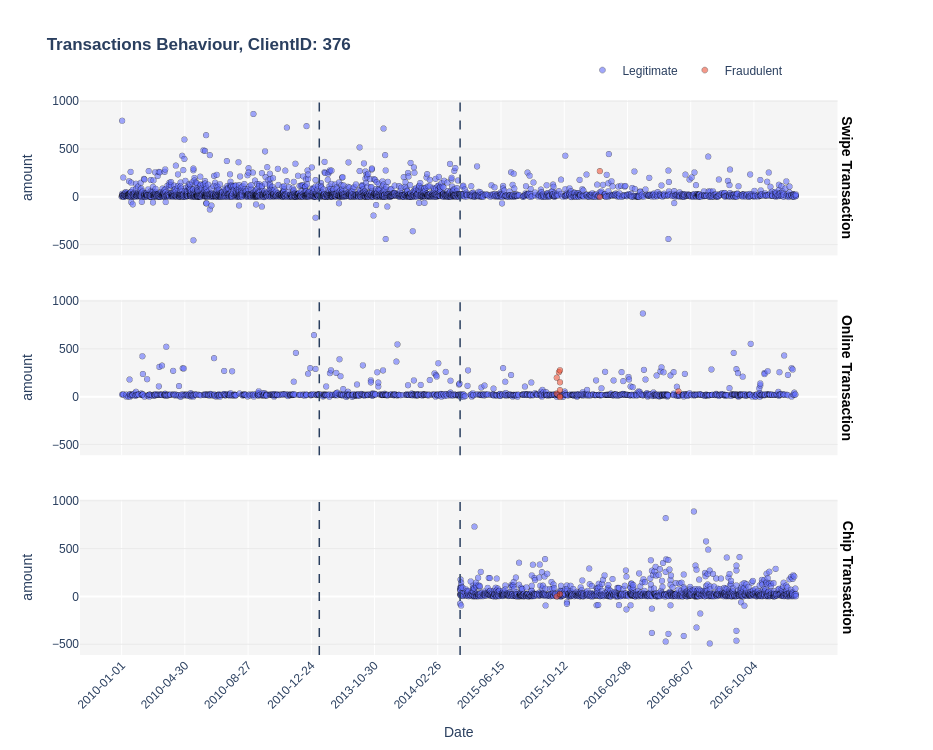

```python
plot_client_behaviour_amount("376")
```

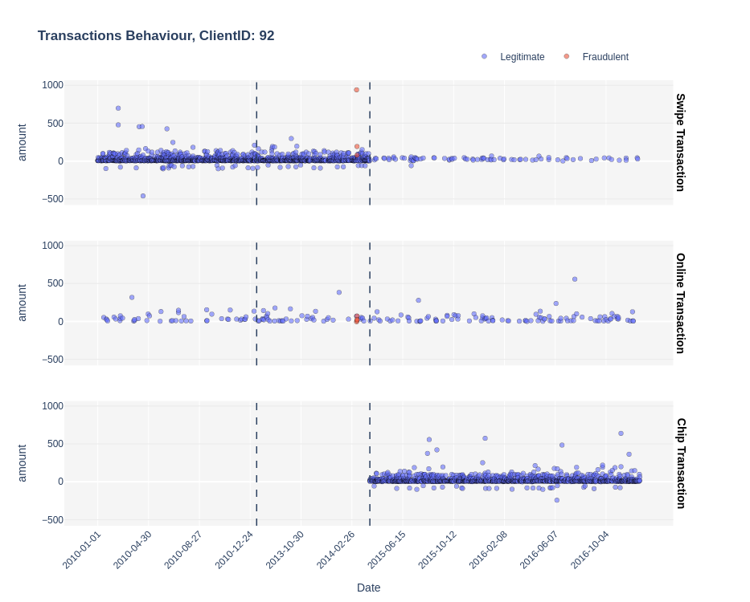

```python
plot_client_behaviour_amount(fraudulent_client_list[1])
```

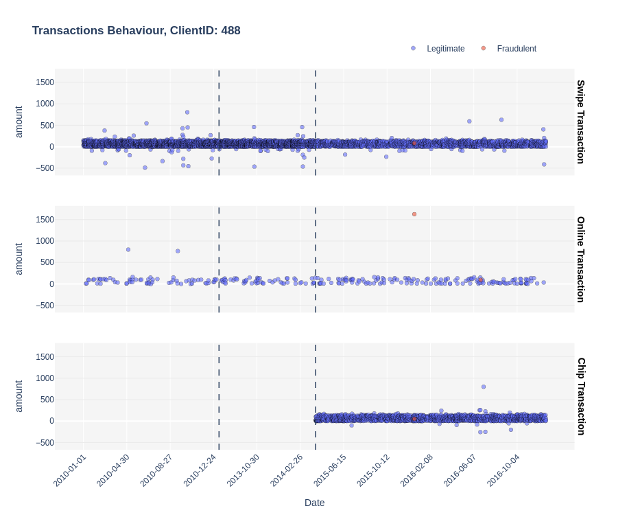

```python
plot_client_behaviour_amount(fraudulent_client_list[2])
```

### **3.5. Análisis Exploratorio de Datos Espaciales**

```python
import polars as pl
import plotly.express as px
import plotly.graph_objects as go
from plotly.subplots import make_subplots
from datetime import date
path = "/home/jovyan/work/data/bronze/Polars/"
```

```python
!ls $path
```

```
complete_fraud_data.parquet
```

```python
location_fraud_unbiased_df = (
    pl.scan_parquet(f"{path}complete_fraud_data.parquet")
    .with_columns(day = pl.col("date").cast(pl.Date))
    .filter(
        # ((pl.col("day").is_between(date(2010, 1, 1), date(2011, 1, 8))) |
        #  (pl.col("day").is_between(date(2013, 7, 19), date(2014, 4, 8))) |
        #  (pl.col("day").is_between(date(2015, 3, 30), date(2016, 12, 22)))
        # ) &
        # (pl.col("day") != date(2016, 2, 29)) &
        (pl.col("target").is_not_null())
    )
    .with_columns(
        target = pl.when(pl.col("target")).then(pl.lit("Fraudulent")).otherwise(pl.lit("Legitimate")),
        merchant_state = pl.col("merchant_state").fill_null("No_Country")
    )
    .select("merchant_city", "merchant_state", "zip",
            "merchant_latitude", "merchant_longitude",
            "client_latitude", "client_longitude",
            "amount", "use_chip", "day", "target", "client_id")
)


Rows = location_fraud_unbiased_df.select(pl.len()).collect().item()
Columns = len(location_fraud_unbiased_df.collect_schema().names())

print(f"Rows: {Rows}, Columns: {Columns}")
location_fraud_unbiased_df.show(5)
```

shape: (5, 12)

| merchant_city str | merchant_state str | zip str | merchant_latitude f64 | merchant_longitude f64 | client_latitude f64 | client_longitude f64 | amount f64 | use_chip cat | day date | target str | client_id str |
| --- | --- | --- | --- | --- | --- | --- | --- | --- | --- | --- | --- |
| "Arcadia" | "CA" | "91007" | 34.1243 | -118.0515 | 32.61 | -117.03 | 10.64 | "Swipe Transaction" | 2010-01-01 | "Legitimate" | "822" |
| "Houston" | "TX" | "77052" | 29.7633 | -95.3633 | 40.6 | -74.76 | 6.71 | "Swipe Transaction" | 2010-01-01 | "Legitimate" | "1147" |
| "Clinton" | "TN" | "37716" | 36.0869 | -84.1897 | 36.09 | -84.13 | -90.0 | "Swipe Transaction" | 2010-01-01 | "Legitimate" | "1541" |
| "Bristol" | "NH" | "03222" | 43.612 | -71.7507 | 43.6 | -71.74 | 8.6 | "Swipe Transaction" | 2010-01-01 | "Legitimate" | "148" |
| "Thackerville" | "OK" | "73459" | 33.7882 | -97.1363 | 42.68 | -89.01 | 72.85 | "Swipe Transaction" | 2010-01-01 | "Legitimate" | "1248" |

```python
n_states = location_fraud_unbiased_df.select(pl.col('merchant_state').n_unique()).collect().item()
print(f"Number of states: {n_states}")
```

```
Number of states: 200
```

```python
USA_states = [
    "CA", "NY", "TX", "FL", "ID", "CT", "IL", "PA", "OH", "GA",
    "MI", "NC", "NJ", "VA", "WA", "AZ", "AK", "AL", "AR", "CO",
    "DE", "HI", "IA", "IN", "KS", "KY", "LA", "MA", "MD", "ME",
    "MN", "MO", "MS", "MT", "ND", "NE", "NH", "NM", "NV", "OK",
    "OR", "RI", "SC", "SD", "TN", "UT", "VT", "WI", "WV", "WY",
    "DC"
]

location_fraud_unbiased_df = (
    location_fraud_unbiased_df
    .with_columns(
        merchant_country = pl.when(pl.col("merchant_state").is_in(USA_states))
                             .then(pl.lit("USA")).otherwise(pl.col("merchant_state"))
    )
)

location_fraud_unbiased_df.show(5)
```

shape: (5, 13)

| merchant_city str | merchant_state str | zip str | merchant_latitude f64 | merchant_longitude f64 | client_latitude f64 | client_longitude f64 | amount f64 | use_chip cat | day date | target str | client_id str | merchant_country str |
| --- | --- | --- | --- | --- | --- | --- | --- | --- | --- | --- | --- | --- |
| "Arcadia" | "CA" | "91007" | 34.1243 | -118.0515 | 32.61 | -117.03 | 10.64 | "Swipe Transaction" | 2010-01-01 | "Legitimate" | "822" | "USA" |
| "Houston" | "TX" | "77052" | 29.7633 | -95.3633 | 40.6 | -74.76 | 6.71 | "Swipe Transaction" | 2010-01-01 | "Legitimate" | "1147" | "USA" |
| "Clinton" | "TN" | "37716" | 36.0869 | -84.1897 | 36.09 | -84.13 | -90.0 | "Swipe Transaction" | 2010-01-01 | "Legitimate" | "1541" | "USA" |
| "Bristol" | "NH" | "03222" | 43.612 | -71.7507 | 43.6 | -71.74 | 8.6 | "Swipe Transaction" | 2010-01-01 | "Legitimate" | "148" | "USA" |
| "Thackerville" | "OK" | "73459" | 33.7882 | -97.1363 | 42.68 | -89.01 | 72.85 | "Swipe Transaction" | 2010-01-01 | "Legitimate" | "1248" | "USA" |

```python
n_countries = location_fraud_unbiased_df.select(pl.col('merchant_country').n_unique()).collect().item()
print(f"Number of countries: {n_countries}")
```

```
Number of countries: 150
```

```python
fraudulent_countries_df = (
    location_fraud_unbiased_df
    .filter(pl.col("target") == "Fraudulent")
    .select(pl.col("merchant_country").unique())
    .collect()
)

fraudulent_countries_list = fraudulent_countries_df["merchant_country"].to_list()
fraudulent_countries_list
```

```
['Haiti', 'Tuvalu', 'USA', 'Italy', 'No_Country']
```

```python
iso_country = {
    "Haiti": "HTI",
    "Tuvalu": "TUV",
    "Italy": "ITA",
    "USA": "USA"
}

rate_country_fraud_unbiased_df = (
    location_fraud_unbiased_df
    .filter(
        pl.col("merchant_country").is_in(fraudulent_countries_list) &
        (pl.col("merchant_country") != "No_Country")
    )
    .group_by("merchant_country", "target")
    .agg(Total = pl.col("target").len())
    .with_columns(
        fraud_rate = (pl.col("Total") / pl.col("Total").sum().over("target") * 100).round(2),
        merchant_country = pl.col("merchant_country").replace(iso_country)
    )
    .sort("Total", descending=True)
    .collect()
)

rate_country_fraud_unbiased_df.show(10)
```

shape: (7, 4)

| merchant_country str | target str | Total u32 | fraud_rate f64 |
| --- | --- | --- | --- |
| "USA" | "Legitimate" | 7806349 | 99.98 |
| "ITA" | "Fraudulent" | 3061 | 67.23 |
| "ITA" | "Legitimate" | 1645 | 0.02 |
| "USA" | "Fraudulent" | 1234 | 27.1 |
| "HTI" | "Fraudulent" | 253 | 5.56 |
| "HTI" | "Legitimate" | 11 | 0.0 |
| "TUV" | "Fraudulent" | 5 | 0.11 |

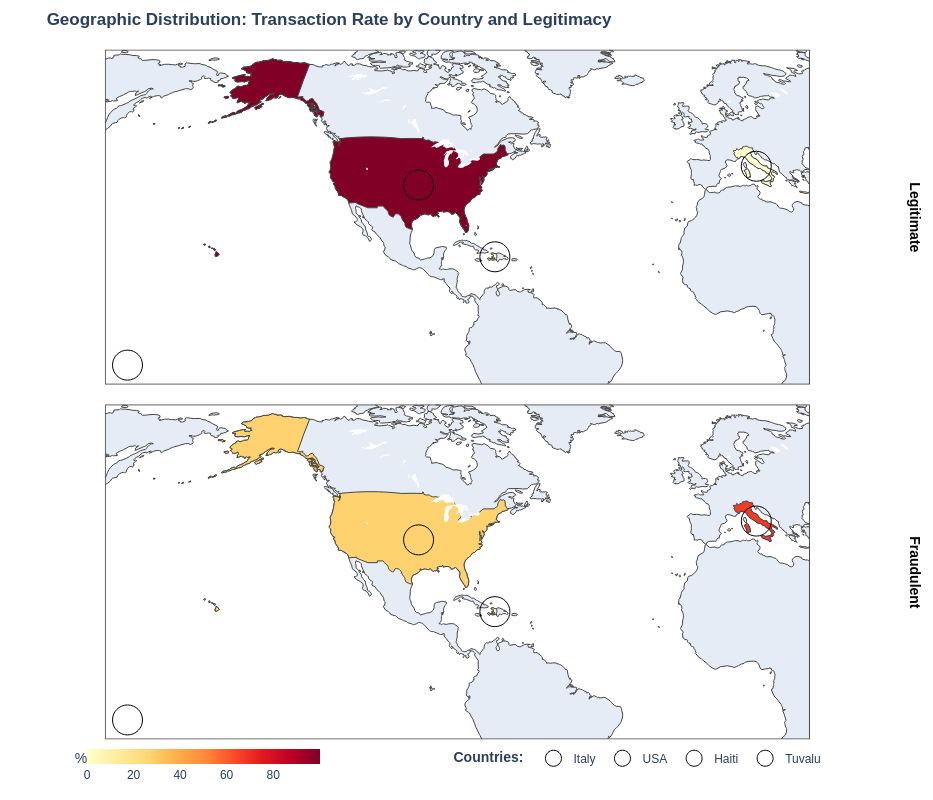

```python
min_tasa = rate_country_fraud_unbiased_df['fraud_rate'].min()
max_tasa = rate_country_fraud_unbiased_df['fraud_rate'].max()

rate_country_fraud_unbiased_map = px.choropleth(
    rate_country_fraud_unbiased_df,
    locations="merchant_country",
    locationmode="ISO-3",
    color="fraud_rate",
    facet_row="target",
    scope="world",
    color_continuous_scale="YlOrRd",
    range_color=[min_tasa, max_tasa],
    title="<b>Geographic Distribution: Transaction Rate by Country and Legitimacy</b>",
    labels={"fraud_rate": "Transactions(%)", "merchant_country": "País"}
)


rate_country_fraud_unbiased_map.update_geos(
    projection_type="natural earth",
    lakecolor="white", showlakes=True,
    lataxis_range=[-13, 71],
    lonaxis_range=[-187, 20]
)

coords = {
    'Italy': {'lat': 41.87, 'lon': 12.56},
    'USA': {'lat': 37.09, 'lon': -95.71},
    'Haiti': {'lat': 18.97, 'lon': -72.28},
    'Tuvalu': {'lat': -8.52, 'lon': 179.21}
}

for pais, pos in coords.items():
    rate_country_fraud_unbiased_map.add_trace(
        go.Scattergeo(
            lat=[pos['lat']], lon=[pos['lon']],
            name=pais,
            mode='markers',
            marker=dict(size=30, color='black', symbol='circle-open', opacity=1),
            showlegend=True,
            hoverinfo="skip",
            geo="geo"
        )
    )
    rate_country_fraud_unbiased_map.add_trace(
        go.Scattergeo(
            lat=[pos['lat']], lon=[pos['lon']],
            name=pais,
            mode='markers',
            marker=dict(size=30, color='black', symbol='circle-open', opacity=1),
            showlegend=False,
            hoverinfo="skip",
            geo="geo2"
        )
    )

rate_country_fraud_unbiased_map.update_layout(
    title_x=0.05,
    width=900, height=800, autosize=False,
    margin=dict(l=10, r=10, t=50, b=50),
    coloraxis_colorbar=dict(
        title="%",
        orientation="h", thickness=15, len=0.3,
        xanchor="center", x=0.2,
        yanchor="top",  y= -0.
    ),
    legend=dict(
        orientation="h",
        yanchor="bottom", y=-0.049,
        xanchor="center", x=0.69,
        title_text="<b>Countries:</b>"
    )
)

rate_country_fraud_unbiased_map.for_each_annotation(lambda a: a.update(
    text=f"<b>{a.text.split('=')[-1]}</b>",
    font=dict(size=14, color="black")
    )
)

rate_country_fraud_unbiased_map.show()
```

```python
chip_color = {
    'Online Transaction': '#7EA1B5',
    'Swipe Transaction': '#F2A183',
    'Chip Transaction': '#89D3C2'
}
```

```python
number_country_fraud_unbiased_df = (
    location_fraud_unbiased_df
    .filter(pl.col("merchant_country").is_in(fraudulent_countries_list))
    .group_by("merchant_country", "target", "use_chip")
    .agg(Total = pl.col("target").len())
    .sort("Total", descending=True)
    .collect()
)

number_country_fraud_unbiased_df.show(5)
```

shape: (5, 4)

| merchant_country str | target str | use_chip cat | Total u32 |
| --- | --- | --- | --- |
| "USA" | "Legitimate" | "Swipe Transaction" | 4634888 |
| "USA" | "Legitimate" | "Chip Transaction" | 3171461 |
| "No_Country" | "Legitimate" | "Online Transaction" | 1035196 |
| "No_Country" | "Fraudulent" | "Online Transaction" | 8779 |
| "No_Country" | "Legitimate" | "Chip Transaction" | 3890 |

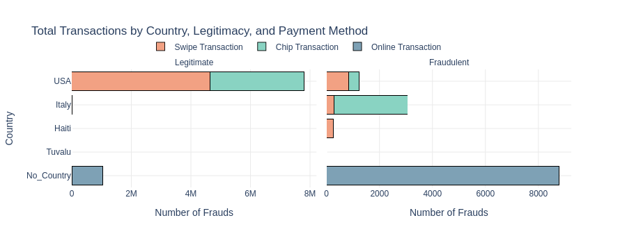

```python
number_country_fraud_unbiased_fig = px.bar(
    number_country_fraud_unbiased_df,
    x="Total",
    y="merchant_country",
    color="use_chip",
    facet_col= "target",
    orientation="h",
    barmode="stack",
    title="Total Transactions by Country, Legitimacy, and Payment Method",
    color_discrete_map= chip_color,
        labels={"Total": "Number of Frauds", "merchant_country": "Country",
            "use_chip": "Payment Method"}
)

number_country_fraud_unbiased_fig.update_traces(
    marker_line_color='black', marker_line_width=0.9
)

number_country_fraud_unbiased_fig.update_xaxes(matches=None, showgrid=True, gridcolor="#EAEAEA")
number_country_fraud_unbiased_fig.update_yaxes(autorange="reversed", showgrid=True, gridcolor="#EAEAEA")

number_country_fraud_unbiased_fig.update_layout(
    plot_bgcolor="white", paper_bgcolor="white",
    width=900, height=350, autosize=False,
    legend=dict(title="", orientation="h", yanchor="top", y=1.28, xanchor="left", x=0.15)
)

number_country_fraud_unbiased_fig.for_each_annotation(lambda a: a.update(text=a.text.split('=')[-1]))

number_country_fraud_unbiased_fig.show()
```

```python
amount_country_fraud_unbiased_df = (
    location_fraud_unbiased_df
    .filter(pl.col("merchant_country").is_in(fraudulent_countries_list))
    .group_by("merchant_country", "target", "use_chip")
    .agg(Total = pl.col("amount").sum())
    .sort("Total", descending=True)
    .collect()
)

amount_country_fraud_unbiased_df.show(5)
```

shape: (5, 4)

| merchant_country str | target str | use_chip cat | Total f64 |
| --- | --- | --- | --- |
| "USA" | "Legitimate" | "Swipe Transaction" | 1.9111e8 |
| "USA" | "Legitimate" | "Chip Transaction" | 1.2990e8 |
| "No_Country" | "Legitimate" | "Online Transaction" | 5.8667e7 |
| "No_Country" | "Fraudulent" | "Online Transaction" | 1.0616e6 |
| "Italy" | "Fraudulent" | "Chip Transaction" | 238236.91 |

En la lista del volumen de dinero de transaccciones por chip, observamos que aquellos sitios donde no hay un registro del pais la suma es negativa (en la anterior tabla observamos que este subconjunto representa un total de 3890 operaciones), deducimos que esto es por alguna particularidad de la naturaleza de algunos reembolsos por chip o por algún error o sesgo del dataset. Dado que este número es ínfimo en comparación al resto de transacciones legítimas sin país atribuido, continuaremos con la forma de representar los gráficos, y evitaremos el uso de gráficos de divergencia

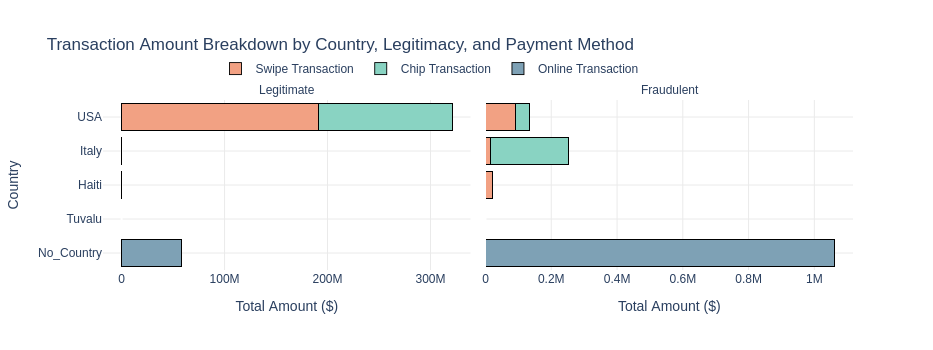

```python
amount_country_fraud_unbiased_fig = px.bar(
    amount_country_fraud_unbiased_df,
    x="Total",
    y="merchant_country",
    color="use_chip",
    facet_col = "target",
    orientation="h",
    barmode="stack",
    title="Transaction Amount Breakdown by Country, Legitimacy, and Payment Method",
    color_discrete_map= chip_color,
    labels={"Total": "Amount", "merchant_country": "Country",
            "use_chip": "Payment Method"}
)

amount_country_fraud_unbiased_fig.update_traces(
    marker_line_color='black', marker_line_width=0.9
)

amount_country_fraud_unbiased_fig.update_xaxes(matches=None, showgrid=True, gridcolor="#EAEAEA",
                                              title="Total Amount ($)")
amount_country_fraud_unbiased_fig.update_yaxes(autorange="reversed", showgrid=True, gridcolor="#EAEAEA")

amount_country_fraud_unbiased_fig.update_layout(
    plot_bgcolor="white", paper_bgcolor="white",
    width=900, height=350, autosize=False,
    legend=dict(title="", orientation="h", yanchor="top", y=1.27, xanchor="left", x=0.15)
)

amount_country_fraud_unbiased_fig.for_each_annotation(lambda a: a.update(text=a.text.split('=')[-1]))

amount_country_fraud_unbiased_fig.show()
```

```python
count_year_fraud_df = (
    location_fraud_unbiased_df
    .filter((pl.col("target") == 'Fraudulent'))
    .select("merchant_country", "day")
    .group_by("day", "merchant_country")
    .len()
    .collect()
)

count_year_fraud_df.show(5)
```

shape: (5, 3)

| day date | merchant_country str | len u32 |
| --- | --- | --- |
| 2016-02-16 | "No_Country" | 23 |
| 2010-01-13 | "Tuvalu" | 1 |
| 2010-01-27 | "No_Country" | 1 |
| 2010-02-12 | "No_Country" | 17 |
| 2010-01-09 | "No_Country" | 1 |

```python
country_color = {
    'USA': '#636EFA',
    'Italy': '#FFA15A',
    'Haiti': '#EF553B',
    'Tuvalu': '#AB63FA',
    'No_Country': '#00CC96'
}
country_order= ['Italy', 'No_Country', 'USA', 'Haiti', 'Tuvalu']
```

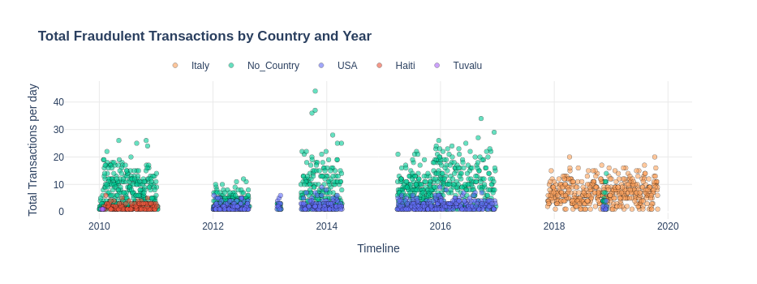

```python
count_year_fraud_fig = px.scatter(
    count_year_fraud_df,
    x="day",
    y="len",
    color="merchant_country",
    opacity=0.6,
    category_orders={"merchant_country": country_order},
    color_discrete_map= country_color,
    title="<b>Total Fraudulent Transactions by Country and Year</b>",
    labels={"day": "Timeline", "len": "Total Transactions per day",
            "merchant_country": ""}
)

count_year_fraud_fig.update_traces(
    marker=dict(line=dict(color='black', width=0.45)))

count_year_fraud_fig.update_layout(
    plot_bgcolor="white", paper_bgcolor="white",
    width=900, height=350, autosize=False,
    xaxis=dict(showgrid=True, gridcolor="#EAEAEA"),
    yaxis=dict(showgrid=True, gridcolor="#EAEAEA"),
    legend=dict(title="", orientation="h", yanchor="top", y=1.2, xanchor="left", x=0.15)
)

count_year_fraud_fig.show()
```